# Homework-4

Vamsee Krishna Reddy Narahari

2022-12-03

```r
df_automobile <- read.csv("Automobile Service Center Ratings.csv")
head(df_automobile,2)
```

```
##   Quality Fairness Guarantee Checkout Return Comment
## 1       2        3         3        3      2       3
## 2       3        3         3        3      2       3
```

## Question 1.a

```
## Objective: To check if the customers who are returning rating the questions higher than who are not
## Type of Data: Ordinal
## Types of Sample: Independent
## Definition: People who are returning as sample 1 and who are not as sample 2
```

**Hypothesis:**  
$H_{o}$ : The two population locations are the same  
$H_{1}$ : The location of population 1 is to the right of the location of population 2

```r
df_automobile$Return<-factor(df_automobile$Return,levels=c(2,1))
wilcox.test(as.integer(df_automobile$Quality) ~ as.factor(df_automobile$Return),alt='greater',paired = FALSE, exact = FALSE, conf.level=0.95)
```

```
##
##  Wilcoxon rank sum test with continuity correction
##
## data:  as.integer(df_automobile$Quality) by as.factor(df_automobile$Return)
## W = 2283.5, p-value = 2.327e-08
## alternative hypothesis: true location shift is greater than 0
```

```
## Interpretation: The data provides sufficient evidence to infer that the customers who are returning rating the quality question higher than who are not
```

```
## The Objective and other steps would be almost similar to the ones mentioned above for the remaining questions
```

```r
wilcox.test(as.integer(df_automobile$Fairness) ~ as.factor(df_automobile$Return),alt='greater',paired = FALSE, exact = FALSE, conf.level=0.95)
```

```
##
##  Wilcoxon rank sum test with continuity correction
##
## data:  as.integer(df_automobile$Fairness) by as.factor(df_automobile$Return)
## W = 1682, p-value = 0.04868
## alternative hypothesis: true location shift is greater than 0
```

```
## Interpretation: The data provides sufficient evidence to infer that the customers who are returning rating the Fairness question higher than who are not
```

```r
wilcox.test(as.integer(df_automobile$Guarantee) ~ as.factor(df_automobile$Return),alt='greater',paired = FALSE, exact = FALSE, conf.level=0.95)
```

```
##
##  Wilcoxon rank sum test with continuity correction
##
## data:  as.integer(df_automobile$Guarantee) by as.factor(df_automobile$Return)
## W = 1503, p-value = 0.278
## alternative hypothesis: true location shift is greater than 0
```

[output not shown]

```r
wilcox.test(as.integer(df_automobile$Checkout) ~ as.factor(df_automobile$Return),alt='greater',paired = FALSE, exact = FALSE, conf.level=0.95)
```

```
##
##  Wilcoxon rank sum test with continuity correction
##
## data:  as.integer(df_automobile$Checkout) by as.factor(df_automobile$Return)
## W = 1698, p-value = 0.03943
## alternative hypothesis: true location shift is greater than 0
```

```
## Interpretation: The data provides sufficient evidence to infer that the customers who are returning rating the Checkout question higher than who are not
```

## Question 1.b

```
## Objective: To check if the customers rating of the questions differ based on their comment sentiment
## Type of Data: Ordinal
## Types of Sample: Independent
## Definition: Denote Positive Comment - Population 1, No comment - Population 2, Negative Comment - Population 3
```

**Hypothesis:**  
$H_{o}$ : The locations of all three populations are the same.  
$H_{1}$ : At least two population locations differ.

```r
df_automobile$Comment<-factor(df_automobile$Comment,levels=c(1,3,2))
kruskal.test(as.integer(df_automobile$Quality) ~ as.factor(df_automobile$Comment))
```

```
##
##  Kruskal-Wallis rank sum test
##
## data:  as.integer(df_automobile$Quality) by as.factor(df_automobile$Comment)
## Kruskal-Wallis chi-squared = 8.0915, df = 2, p-value = 0.0175
```

```
## The P-value is less than 0.05 significance level, so we decide to reject the null hypothesis and infer that the ratings differe for atleast two of the comment categories
```

```r
kruskal.test(as.integer(df_automobile$Fairness) ~ as.factor(df_automobile$Comment))
```

```
##
##  Kruskal-Wallis rank sum test
##
## data:  as.integer(df_automobile$Fairness) by as.factor(df_automobile$Comment)
## Kruskal-Wallis chi-squared = 3.3456, df = 2, p-value = 0.1877
```

```
## The P-value is greater than 0.05 significance level, so we decide not to reject the null hypothesis
```

```r
kruskal.test(as.integer(df_automobile$Guarantee) ~ as.factor(df_automobile$Comment))
```

```
##
##  Kruskal-Wallis rank sum test
##
## data:  as.integer(df_automobile$Guarantee) by as.factor(df_automobile$Comment)
## Kruskal-Wallis chi-squared = 0.33768, df = 2, p-value = 0.8446
```

```
## The P-value is greater than 0.05 significance level, so we decide not to reject the null hypothesis
```

```r
kruskal.test(as.integer(df_automobile$Checkout) ~ as.factor(df_automobile$Comment))
```

```
##
##  Kruskal-Wallis rank sum test
##
## data:  as.integer(df_automobile$Checkout) by as.factor(df_automobile$Comment)
## Kruskal-Wallis chi-squared = 6.1174, df = 2, p-value = 0.04695
```

```
## The P-value is less than 0.05 significance level, so we decide to reject the null hypothesis and infer that the ratings differ for atleast two of the comment categories
```

# Question-2

```r
df_drink <- read.csv("Soft Drink Recipe.csv")
head(df_drink,2)
```

```
##   Person Original New.Recipe.1 New.Recipe..2
## 1      1        5            5             5
## 2      2        3            4             5
```

```
## Objective: To check if the people rating the three drinks differently
## Type of Data: Ordinal
## Types of Sample: Blocked Design
## Definition:Denote Original Population 1, New Recipe 1- Population-2, New Recipe 2- Population-3
```

**Hypothesis:**  
$H_{o}$ : The locations of all three populations are the same.  
$H_{1}$ : At least two population locations differ.

```r
df_drink_stack <- melt(df_drink, id.vars="Person")
names(df_drink_stack) <- c("Person","Recipe","Rating")
df_drink_stack$Recipe <- factor(df_drink_stack$Recipe, level = c("Original","New.Recipe.1","New.Recipe..2"))
```

```r
friedman.test(df_drink_stack$Rating, as.factor(df_drink_stack$Recipe),as.factor(df_drink_stack$Person))
```

```
##
##  Friedman rank sum test
##
## data:  df_drink_stack$Rating, as.factor(df_drink_stack$Recipe) and as.factor(df_drink_stack$Person)
## Friedman chi-squared = 7.1525, df = 2, p-value = 0.02798
```

```
## Interpretation: As p-value less than 0.05, we can reject the null hypothesis and say that there is significant difference between atleast two recipes
```

```r
library(PMCMRplus)
PMCMRplus::frdAllPairsNemenyiTest(df_drink_stack$Rating, as.factor(df_drink_stack$Recipe),as.factor(df_drink_stack$Person))
```

```
##
##  Pairwise comparisons using Nemenyi-Wilcoxon-Wilcox all-pairs test for a two-way balanced complete block design
```

```
## data: y, groups and blocks
```

```
##               Original New.Recipe.1
## New.Recipe.1  0.559    -
## New.Recipe..2 0.057    0.415
```

```
##
## P value adjustment method: single-step
```

## Question-3

```r
que3_data <- read.csv("Job Loss.csv")
head(que3_data,2)
```

```
##   CASEID SEX AGE HRS1 JOBLOSE
## 1  57062   1  53   60      NA
## 2  57063   2  26   40      NA
```

```
## Objective: To analyze for any relation between job loss probability and number of hours
## Type of Data: Interval and Ordinal
```

**Hypothesis:**  
$H_{o}$ : $\rho_{s}$ = 0  
$H_{1}$ : $\rho_{s}$ $>$ 0.

```r
cor.test(x=que3_data$HRS1,y=(que3_data$JOBLOSE),method = "spearman",alternative='greater')
```

```
##
##  Spearman's rank correlation rho
##
## data:  que3_data$HRS1 and (que3_data$JOBLOSE)
## S = 151103791, p-value = 0.00117
## alternative hypothesis: true rho is greater than 0
## sample estimates:
##        rho
## 0.09609079
```

```
## As the p-value less than the 0.05 significance, we can reject the null hypothesis and conclude that the job loss chances and work hours are related, also we can say that the if longer hours worked, your job loss is less likely
```

## Question-4

```r
df_ice <- read.csv("Ice Cream Comparison.csv")
head(df_ice,2)
```

```
##   European Domestic
## 1        3        2
## 2        5        4
```

```
## Objective: To check if the people prefering European brand even though icecream is same
## Type of Data: Ordinal
## Types of Sample: Blocked Design
## Definition:Denote European Population 1, Domestic - Population-2
```

**Hypothesis:**  
$H_{o}$ : The two population locations are the same  
$H_{1}$ : The location of the population 1 is right to the population 2

```r
SIGN.test(x = df_ice$European, y=df_ice$Domestic, alternative="greater",conf.level = 0.95)
```

```
##
##  Dependent-samples Sign-Test
##
## data:  df_ice$European and df_ice$Domestic
## S = 30, p-value = 0.000236
## alternative hypothesis: true median difference is greater than 0
## 95 percent confidence interval:
##    0 Inf
## sample estimates:
## median of x-y
##           0.5
##
## Achieved and Interpolated Confidence Intervals:
##
##                   Conf.Level L.E.pt U.E.pt
## Lower Achieved CI     0.9225      0    Inf
## Interpolated CI       0.9500      0    Inf
## Upper Achieved CI     0.9538      0    Inf
```

```
## As the p-value less than the significance value, we would be rejecting the Null Hypothesis and infer that the People have brand preference and in this case the customers prefer european bran
```

## Question-5

```r
df_time <- read.csv("Machine Selection.csv")
head(df_time,2)
```

```
##   Key Machine.1 Machine.2
## 1   1        20        21
## 2   2        17        16
```

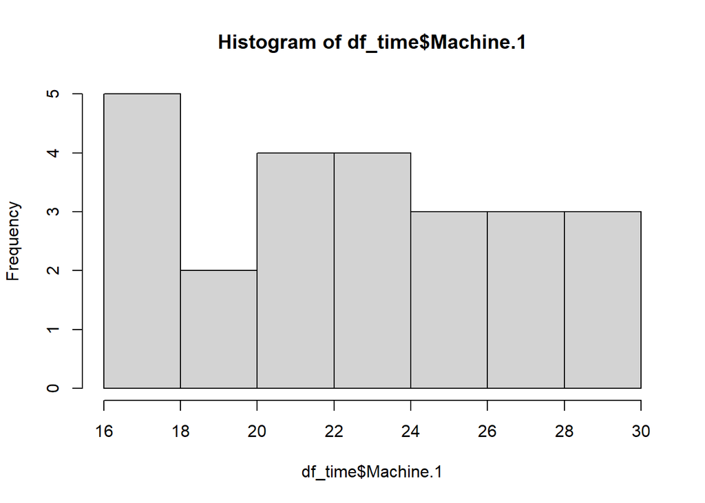

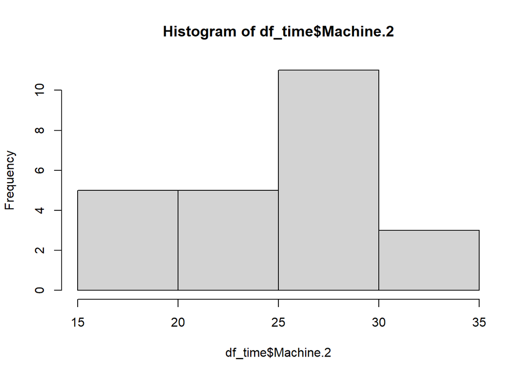

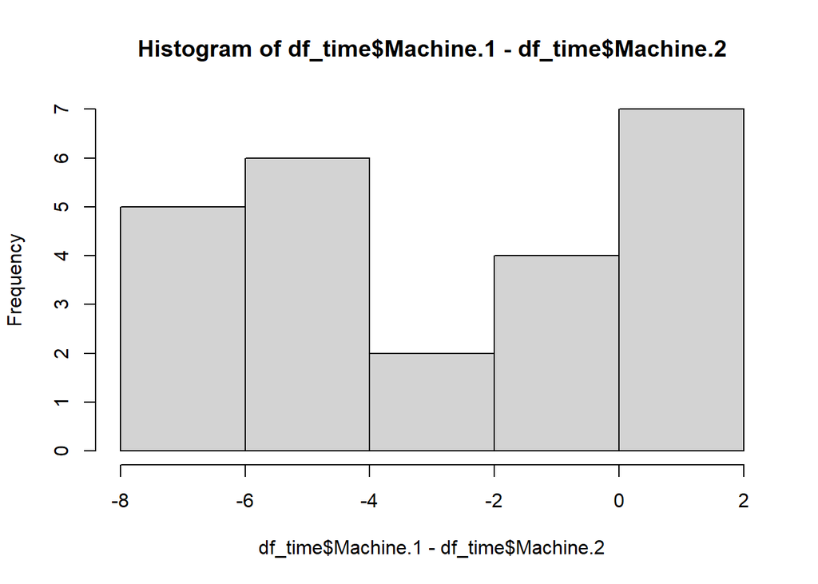

```
## From the above histogram data, we can see that the time differences are not normal in both the category situation. We can work on Wilcoxin Sign Rank Sum test in this case
```

```r
df_time_stack <- melt(df_time, id.vars="Key")
names(df_time_stack) <- c("Key","Machine","Time")
```

```
## Objective: Compare the two machine cutting times
## Type of Data: Interval
## Types of Sample: Blocked Design
## Definition:Machine 1 -Population 1, Machine 2 - Population 2
```

**Hypothesis:**  
$H_{o}$ : The two population locations are the same  
$H_{1}$ : The two populations are different

```r
wilcox.test(df_time_stack$Time~df_time_stack$Machine,alt="two.sided",paired=TRUE,exact=FALSE,conf.level = 0.95)
```

```
##
##  Wilcoxon signed rank test with continuity correction
##
## data:  df_time_stack$Time by df_time_stack$Machine
## V = 40.5, p-value = 0.002937
## alternative hypothesis: true location shift is not equal to 0
```

```
## At 5% significance, we will reject the null hypothesis and infer that the two cutting machines are  different and the locksmith can buy the fastest version
```

## Question-6

```r
df_cred <- read.csv("CreditCardHolders.csv")
head(df_cred,2)
```

```
##   Applied Contacted
## 1  102.13    113.64
## 2  142.27    127.04
```

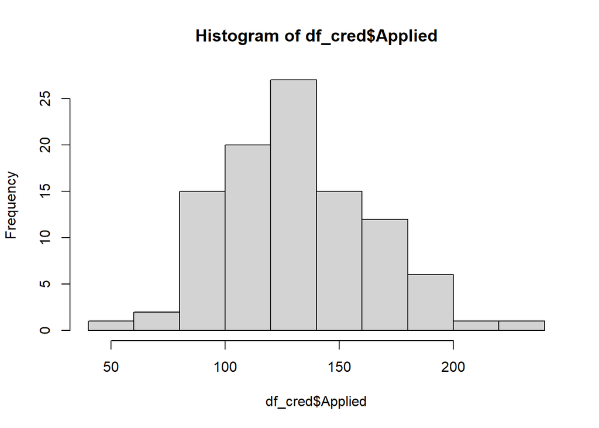

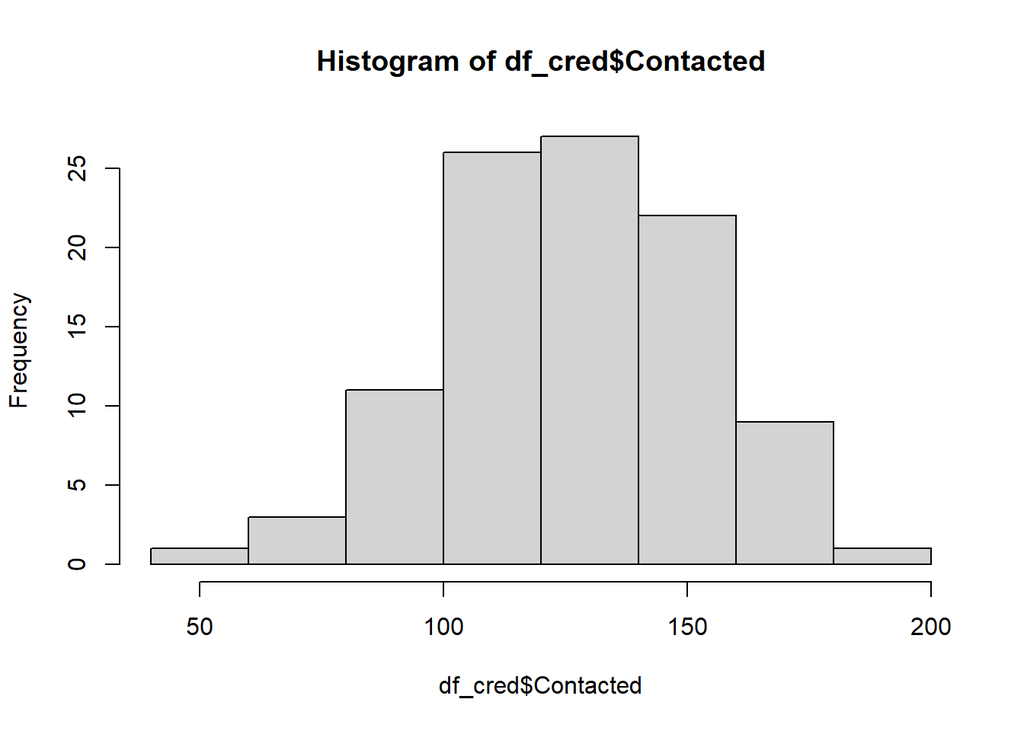

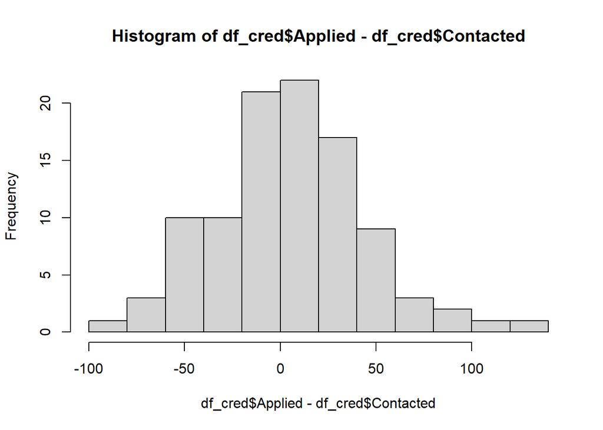

```r
shapiro.test(df_cred$Contacted)
```

```
##
##  Shapiro-Wilk normality test
##
## data:  df_cred$Contacted
## W = 0.99208, p-value = 0.8266
```

```r
shapiro.test(df_cred$Applied)
```

```
##
##  Shapiro-Wilk normality test
##
## data:  df_cred$Applied
## W = 0.97586, p-value = 0.06303
```

```r
shapiro.test(df_cred$Applied-df_cred$Contacted)
```

```
##
##  Shapiro-Wilk normality test
##
## data:  df_cred$Applied - df_cred$Contacted
## W = 0.98468, p-value = 0.3011
```

```
## We can observe normality in the data from the graphs and normality tests, so we can infer that the normality exists
```

```r
var.test(df_cred$Applied,df_cred$Contacted)
```

```
##
##  F test to compare two variances
##
## data:  df_cred$Applied and df_cred$Contacted
## F = 1.5142, num df = 99, denom df = 99, p-value = 0.04022
## alternative hypothesis: true ratio of variances is not equal to 1
## 95 percent confidence interval:
##  1.018797 2.250412
## sample estimates:
## ratio of variances
##           1.514171
```

```
## From the variance test, we can infer that the variances of the two samples are not equal
```

```
## Objective: Compare the purchases of the two ways customers are coming in
## Type of Data: Interval
## Types of Sample: Independent samples
## Definition:Directly Applied -Population 1, Via Email/Telemarketing - Population 2
```

**Hypothesis:**  
$H_{o}$ : $\mu{1}$ $=$ $\mu{2}$  
$H_{1}$ : $\mu{1}$ $\neq$ $\mu{2}$

```r
t.test(df_cred$Applied,df_cred$Contacted,
       var.equal = F,
       mu = 0,
       alternative = "t")
```

```
##
##  Welch Two Sample t-test
##
## data:  df_cred$Applied and df_cred$Contacted
## t = 1.1619, df = 190.05, p-value = 0.2467
## alternative hypothesis: true difference in means is not equal to 0
## 95 percent confidence interval:
##  -3.341448 12.920648
## sample estimates:
## mean of x mean of y
##  130.9252  126.1356
```

```
## As the p-value is greater than 0.05, we cannot reject the null hypothesis and there is no statistically significant evidence that the two purchase populations are different
```

## Question-7

```r
df_debt <- read.csv("AmericanDebt.csv")
head(df_debt,2)
```

```
##   This.Year Last.Year
## 1     0.537     0.409
## 2     0.534     0.485
```

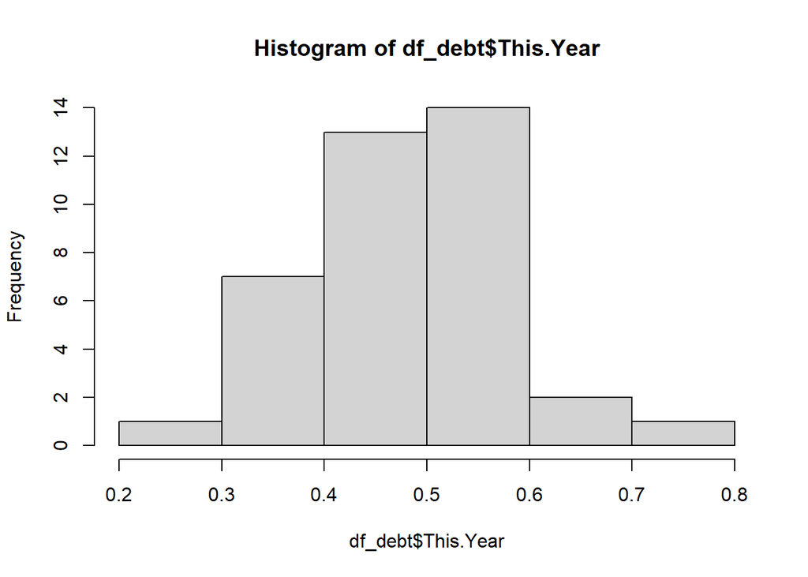

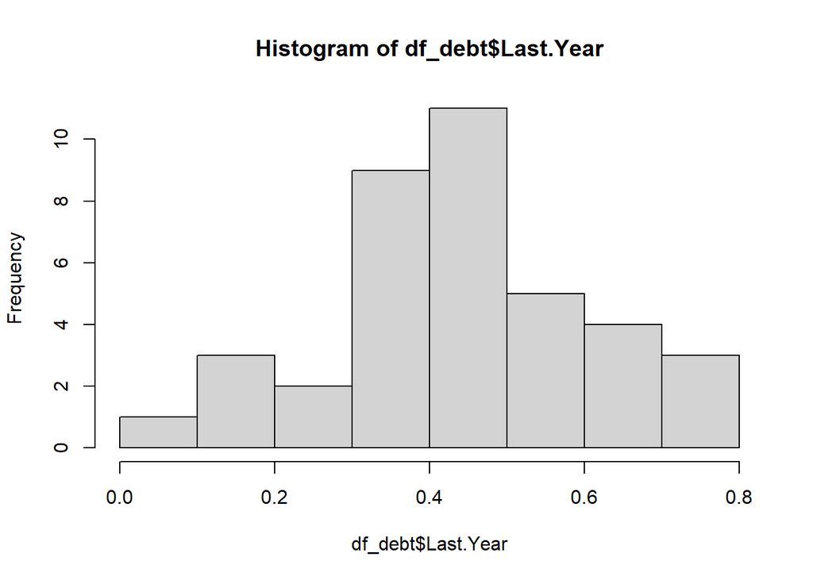

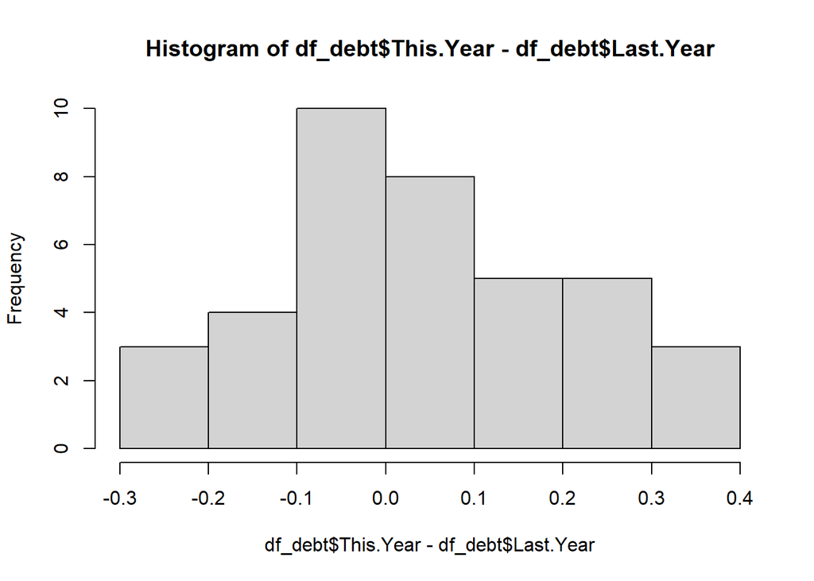

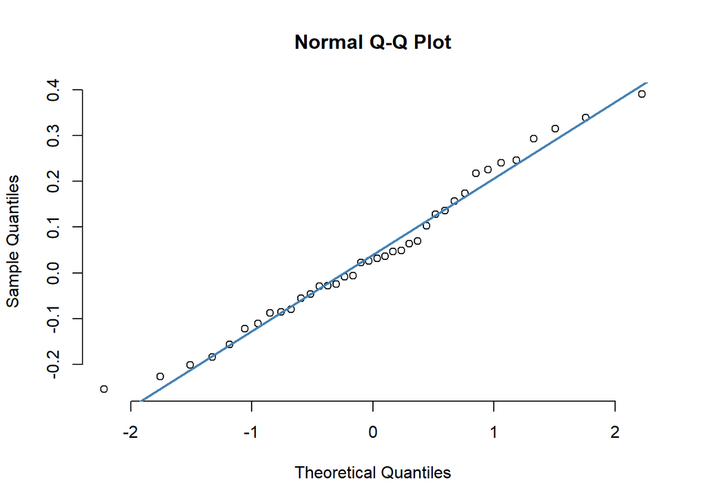

```r
qqnorm(df_debt$This.Year-df_debt$Last.Year, pch = 1, frame = FALSE)
qqline(df_debt$This.Year-df_debt$Last.Year, col = "steelblue", lwd = 2)
```

```r
shapiro.test(df_debt$This.Year)
```

```
##
##  Shapiro-Wilk normality test
##
## data:  df_debt$This.Year
## W = 0.98507, p-value = 0.8827
```

```r
shapiro.test(df_debt$Last.Year)
```

```
##
##  Shapiro-Wilk normality test
##
## data:  df_debt$Last.Year
## W = 0.9833, p-value = 0.8299
```

```r
shapiro.test(df_debt$This.Year-df_debt$Last.Year)
```

```
##
##  Shapiro-Wilk normality test
##
## data:  df_debt$This.Year - df_debt$Last.Year
## W = 0.97897, p-value = 0.6808
```

```
## We can observe normality in the data from the graphs and normality tests, so we can infer that the normality exists
```

```r
var.test(df_debt$This.Year,df_debt$Last.Year)
```

```
##
##  F test to compare two variances
##
## data:  df_debt$This.Year and df_debt$Last.Year
## F = 0.38897, num df = 37, denom df = 37, p-value = 0.005073
## alternative hypothesis: true ratio of variances is not equal to 1
## 95 percent confidence interval:
##  0.2021541 0.7484173
## sample estimates:
## ratio of variances
##          0.3889674
```

[output not shown]

```r
var.test(df_debt$This.Year,df_debt$Last.Year)
```

```
##
##  F test to compare two variances
##
## data:  df_debt$This.Year and df_debt$Last.Year
## F = 0.38897, num df = 37, denom df = 37, p-value = 0.005073
## alternative hypothesis: true ratio of variances is not equal to 1
## 95 percent confidence interval:
##  0.2021541 0.7484173
## sample estimates:
## ratio of variances
##          0.3889674
```

```r
t.test(df_debt$This.Year,df_debt$Last.Year,
       var.equal = F, paired = TRUE,
       mu = 0,
       alternative = "greater")
```

```
##
##  Paired t-test
##
## data:  df_debt$This.Year and df_debt$Last.Year
## t = 1.5939, df = 37, p-value = 0.05974
## alternative hypothesis: true mean difference is greater than 0
## 95 percent confidence interval:
##  -0.002470128          Inf
## sample estimates:
## mean difference
##      0.04223684
```

```
## As the p-value greater than 0.05, we cannot reject our null hypothesis and infer that there is no statistical evidence that this year Americans are in more debt than last year
```

# Question-8

```r
df_ben <- read.csv("Benefits Comparison.csv")
head(df_ben,2)
```

```
##    Benefit Retention
## 1   Health         0
## 2 Vacation         1
```

# 8.a

```
## Some of cofounding variables would be:
## 1. People on the different geographies might have different preferences.
## 2. Environment, work culture, and health costs variation between the two extreme coasts might influence the employee preferences.
## These might cause influence their decision in turn applying the same policy to entire company might not be right decision
```

# 8.b

```
## Objective: To determine if the health benefits causing higher retention
## Level of Measurement: Nominal
## Experiment: Independent
## Definition:
```

**Hypothesis:**  
$H_{o}$ : $P_{1}$ $-$ $P_{2}$ = 0.05  
$H_{1}$ : $P_{1}$ $-$ $P_{2}$ > 0.05

```r
df_ben %>% group_by(Benefit) %>% summarise(count = n(),
                                                 retained = sum(Retention))
```

```
## # A tibble: 2 × 3
##   Benefit  count retained
##   <chr>    <int>    <int>
## 1 Health     125      107
## 2 Vacation   140      109
```

```r
p1 <- 107/125
p2 <- 109/140
n1 <- 125
n2 <- 140
C <- 0.05
SE = sqrt((p1*(1-p1)/n1 + p2*(1-p2)/n2))
z = ((p1 - p2) - C)/SE
1 - pnorm(abs(z))
```

```
## [1] 0.2801272
```

```
## As the p-value greater than any significance vlaue, we won't be reject the null hypothesis and we can't say that health benefits is better in providing the better employee retention
```

# 8.c

**Hypothesis:**  
$H_{o}$ : $P_{1}$ $-$ $P_{2}$ = 0  
$H_{1}$ : $P_{1}$ $-$ $P_{2}$ $\neq$ 0

```r
prop.test(x= c(107,109),n=c(125,140),alternative = "two.sided",correct = F)
```

```
##
##  2-sample test for equality of proportions without continuity correction
##
## data:  c(107, 109) out of c(125, 140)
## X-squared = 2.6269, df = 1, p-value = 0.1051
## alternative hypothesis: two.sided
## 95 percent confidence interval:
##  -0.01486734  0.16972448
## sample estimates:
##    prop 1    prop 2
## 0.8560000 0.7785714
```

```
## As the p-value is greater than 0.05, we failed to reject the null hypothesis and infer that there is no significant difference between the two benefits on the retention
```

# Question-9

```r
df_wage <- read.csv("Wage.csv")
head(df_wage,2)
```

```
##   ID Wage Educ Exper
## 1  1 5.10    8    21
## 2  2 4.95    9    42
```

```r
wage <- lm(df_wage$Wage ~ df_wage$Educ + df_wage$Exper)
summary(wage)
```

```
##
## Call:
## lm(formula = df_wage$Wage ~ df_wage$Educ + df_wage$Exper)
##
## Residuals:
##    Min     1Q Median     3Q    Max
## -8.274 -2.848 -0.591  2.010 36.145
##
## Coefficients:
##               Estimate Std. Error t value Pr(>|t|)
## (Intercept)   -4.52447    1.23935  -3.651 0.000288 ***
## df_wage$Educ   0.91302    0.08219  11.109  < 2e-16 ***
## df_wage$Exper  0.09681    0.01772   5.464 7.25e-08 ***
## ---
## Signif. codes:  0 '***' 0.001 '**' 0.01 '*' 0.05 '.' 0.1 ' ' 1
##
## Residual standard error: 4.624 on 520 degrees of freedom
## Multiple R-squared:  0.195,  Adjusted R-squared:  0.1919
## F-statistic: 62.96 on 2 and 520 DF,  p-value: < 2.2e-16
```

```r
wage_resid <- abs(wage$residuals)
```

```r
cor.test(wage_resid,df_wage$Educ,
         alternative = 'greater',
         method = "spearman",
         exact = FALSE)
```

```
##
##  Spearman's rank correlation rho
##
## data:  wage_resid and df_wage$Educ
## S = 18213931, p-value = 2.337e-08
## alternative hypothesis: true rho is greater than 0
## sample estimates:
##       rho
## 0.2360737
```

```r
cor.test(wage_resid,df_wage$Exper,
         alternative = 'greater',
         method = "spearman",
         exact = FALSE)
```

```
##
##  Spearman's rank correlation rho
##
## data:  wage_resid and df_wage$Exper
## S = 21950708, p-value = 0.03491
## alternative hypothesis: true rho is greater than 0
## sample estimates:
##       rho
## 0.0793463
```

```
## As the p-value for both the tests less than 0.05, we reject the null hypothesis and infer there is sign of heteroscedasticity due to both the experience and education level variables
```

## Question-10

```r
df_comp <- read.csv("Compensation.csv")
df_comp <- df_comp %>%  row_to_names(row_number = 1)
head(df_comp,2)
```

```
##   INDUSTRY 1 to 4 5 to 9 10 to 19 20 to 49 50 to 99 100 to 249 250 to 499
## 2        1   2994   3295     3565     3907     4189       4486       4676
## 3        2   1721   2057     3336     3320     2980       2848       3072
##   500 to 999 1000 to 2499
## 2       4968         5342
## 3       2969         3822
```

```r
df_comp_avg <- tail(df_comp, n = 3)
df_comp_avg <- data.frame(t(df_comp_avg) %>% row_to_names(row_number = 1))
colnames(df_comp_avg) <- c("Average_Compensation","Std_Dev","Average_Productivity")
df_comp_avg$Average_Compensation <- as.numeric(df_comp_avg$Average_Compensation)
df_comp_avg$Average_Productivity <- as.numeric(df_comp_avg$Average_Productivity)
```

```r
com_prod <- lm(df_comp_avg$Average_Compensation~df_comp_avg$Average_Productivity)
summary(com_prod)
```

```
##
## Call:
## lm(formula = df_comp_avg$Average_Compensation ~ df_comp_avg$Average_Productivity)
##
## Residuals:
##    Min     1Q Median     3Q    Max
## -766.0   63.8  112.4  152.7  216.9
##
## Coefficients:
##                                   Estimate Std. Error t value Pr(>|t|)
## (Intercept)                      1.906e+03  9.207e+02   2.070   0.0772 .
## df_comp_avg$Average_Productivity 2.411e-01  9.815e-02   2.457   0.0437 *
## ---
## Signif. codes:  0 '***' 0.001 '**' 0.01 '*' 0.05 '.' 0.1 ' ' 1
##
## Residual standard error: 331.5 on 7 degrees of freedom
## Multiple R-squared:  0.463,  Adjusted R-squared:  0.3863
## F-statistic: 6.036 on 1 and 7 DF,  p-value: 0.04367
```

# Question 10.a

```r
com_pro_res_10a <- com_prod$residuals
```

# Question 10.b

```r
com_pro_res <- log(com_prod$residuals^2)
```

```r
model_log_10b <- lm(com_pro_res ~ log(df_comp_avg$Average_Productivity))
summary(model_log_10b)
```

```
##
## Call:
## lm(formula = com_pro_res ~ log(df_comp_avg$Average_Productivity))
##
## Residuals:
##      Min       1Q   Median       3Q      Max
## -1.82494 -0.48281 -0.09131  0.13765  3.12933
##
## Coefficients:
##                                       Estimate Std. Error t value Pr(>|t|)
## (Intercept)                             32.802     37.780   0.868    0.414
## log(df_comp_avg$Average_Productivity)   -2.477      4.137  -0.599    0.568
##
## Residual standard error: 1.446 on 7 degrees of freedom
## Multiple R-squared:  0.04872,    Adjusted R-squared:  -0.08717
## F-statistic: 0.3585 on 1 and 7 DF,  p-value: 0.5682
```

```
## As the p-value greater than the 0.05, we failed to reject the null hypothesis. So, we can conclude that there is no heteroscadesticity
```

# Question 10.c

```r
comp_resd_10c <- abs(com_prod$residuals)
```

```r
model_log_10c_1 <- lm(comp_resd_10c ~ (df_comp_avg$Average_Productivity))
summary(model_log_10c_1)
```

```
##
## Call:
## lm(formula = comp_resd_10c ~ (df_comp_avg$Average_Productivity))
##
## Residuals:
##     Min      1Q  Median      3Q     Max
## -146.50  -84.48  -50.16  -36.53  554.55
##
## Coefficients:
##                                   Estimate Std. Error t value Pr(>|t|)
## (Intercept)                      383.36479  629.85061   0.609    0.562
## df_comp_avg$Average_Productivity  -0.01838    0.06715  -0.274    0.792
##
## Residual standard error: 226.8 on 7 degrees of freedom
## Multiple R-squared:  0.01059,    Adjusted R-squared:  -0.1308
## F-statistic: 0.07489 on 1 and 7 DF,  p-value: 0.7922
```

```r
model_log_10c <- lm(comp_resd_10c ~ sqrt(df_comp_avg$Average_Productivity))
summary(model_log_10c)
```

```
##
## Call:
## lm(formula = comp_resd_10c ~ sqrt(df_comp_avg$Average_Productivity))
##
## Residuals:
##     Min      1Q  Median      3Q     Max
## -146.08  -84.63  -48.82  -35.32  555.06
##
## Coefficients:
##                                        Estimate Std. Error t value Pr(>|t|)
## (Intercept)                             530.667   1277.428   0.415     0.69
## sqrt(df_comp_avg$Average_Productivity)   -3.306     13.238  -0.250     0.81
##
## Residual standard error: 227 on 7 degrees of freedom
## Multiple R-squared:  0.008829,   Adjusted R-squared:  -0.1328
## F-statistic: 0.06235 on 1 and 7 DF,  p-value: 0.81
```

```
## As the p-value greater than the 0.05, we failed to reject the null hypothesis. So, we can conclude that there is no heteroscadesticity
```

# Question 10.D

```r
cor.test(comp_resd_10c,df_comp_avg$Average_Productivity,
         alternative = 't',
         method = "spearman",
         exact = FALSE)
```

```
##
##  Spearman's rank correlation rho
##
## data:  comp_resd_10c and df_comp_avg$Average_Productivity
## S = 168, p-value = 0.2861
## alternative hypothesis: true rho is not equal to 0
## sample estimates:
##  rho
## -0.4
```

```
## As the p-value greater than the 0.05, we failed to reject the null hypothesis. So, we can conclude that there is no heteroscadesticity
```

## Question-11

```r
df_rd <- read.csv("R&D.csv")
head(df_rd,2)
```

```
##     SALES   RD PROFITS
## 1  6375.3 62.5   185.1
## 2 11626.4 92.9  1569.5
```

```r
rd_sales <- lm(df_rd$RD ~ df_rd$SALES)
summary(rd_sales)
```

```
##
## Call:
## lm(formula = df_rd$RD ~ df_rd$SALES)
##
## Residuals:
##     Min      1Q  Median      3Q     Max
## -5845.9  -950.6  -402.4   346.3  7434.3
##
## Coefficients:
##              Estimate Std. Error t value Pr(>|t|)
## (Intercept) 1.930e+02  9.910e+02   0.195  0.84804
## df_rd$SALES 3.190e-02  8.329e-03   3.830  0.00148 **
## ---
## Signif. codes:  0 '***' 0.001 '**' 0.01 '*' 0.05 '.' 0.1 ' ' 1
##
## Residual standard error: 2759 on 16 degrees of freedom
## Multiple R-squared:  0.4783, Adjusted R-squared:  0.4457
## F-statistic: 14.67 on 1 and 16 DF,  p-value: 0.001476
```

## Park test

```r
resid_rd <- log(rd_sales$residuals^2)

summary(lm(resid_rd ~ log(df_rd$SALES)))
```

```
##
## Call:
## lm(formula = resid_rd ~ log(df_rd$SALES))
##
## Residuals:
##     Min      1Q  Median      3Q     Max
## -7.7901 -0.5624  0.1286  1.4624  3.6718
##
## Coefficients:
##                  Estimate Std. Error t value Pr(>|t|)
## (Intercept)        5.6877     6.6352   0.857    0.404
## log(df_rd$SALES)   0.7014     0.6033   1.163    0.262
##
## Residual standard error: 2.694 on 16 degrees of freedom
## Multiple R-squared:  0.0779, Adjusted R-squared:  0.02027
## F-statistic: 1.352 on 1 and 16 DF,  p-value: 0.262
```

```
## As the p-value greater than 0.05, we failed to reject the null hypothesis and infer that the there is no heteroscadesticity
```

## Glejser test

```r
res_gle <- abs(rd_sales$residuals)

summary(lm(res_gle ~ (df_rd$SALES)))
```

```
##
## Call:
## lm(formula = res_gle ~ (df_rd$SALES))
##
## Residuals:
##     Min      1Q  Median      3Q     Max
## -4054.4  -714.0  -258.9   193.6  4766.1
##
## Coefficients:
##              Estimate Std. Error t value Pr(>|t|)
## (Intercept) 5.786e+02  6.787e+02   0.852   0.4065
## df_rd$SALES 1.194e-02  5.704e-03   2.093   0.0526 .
## ---
## Signif. codes:  0 '***' 0.001 '**' 0.01 '*' 0.05 '.' 0.1 ' ' 1
##
## Residual standard error: 1890 on 16 degrees of freedom
## Multiple R-squared:  0.215,  Adjusted R-squared:  0.1659
## F-statistic: 4.381 on 1 and 16 DF,  p-value: 0.05263
```

```r
summary(lm(res_gle ~ sqrt(df_rd$SALES)))
```

```
##
## Call:
## lm(formula = res_gle ~ sqrt(df_rd$SALES))
##
## Residuals:
##     Min      1Q  Median      3Q     Max
## -3783.2  -758.0   -38.1   182.9  4606.2
##
## Coefficients:
##                   Estimate Std. Error t value Pr(>|t|)
## (Intercept)       -507.020   1007.684  -0.503   0.6217
## sqrt(df_rd$SALES)    7.972      3.363   2.370   0.0307 *
## ---
## Signif. codes:  0 '***' 0.001 '**' 0.01 '*' 0.05 '.' 0.1 ' ' 1
##
## Residual standard error: 1835 on 16 degrees of freedom
## Multiple R-squared:  0.2599, Adjusted R-squared:  0.2136
## F-statistic: 5.619 on 1 and 16 DF,  p-value: 0.03067
```

```r
summary(lm(res_gle ~ I(1/df_rd$SALES)))
```

```
##
## Call:
## lm(formula = res_gle ~ I(1/df_rd$SALES))
##
## Residuals:
##     Min      1Q  Median      3Q     Max
## -2176.9 -1278.8  -508.6    67.8  5274.5
##
## Coefficients:
##                    Estimate Std. Error t value Pr(>|t|)
## (Intercept)       2.274e+03  6.047e+02   3.760  0.00171 **
## I(1/df_rd$SALES) -1.992e+07  1.232e+07  -1.617  0.12531
## ---
## Signif. codes:  0 '***' 0.001 '**' 0.01 '*' 0.05 '.' 0.1 ' ' 1
##
## Residual standard error: 1977 on 16 degrees of freedom
## Multiple R-squared:  0.1405, Adjusted R-squared:  0.08682
## F-statistic: 2.616 on 1 and 16 DF,  p-value: 0.1253
```

```r
summary(lm(res_gle ~ I(1/sqrt(df_rd$SALES))))
```

```
##
## Call:
## lm(formula = res_gle ~ I(1/sqrt(df_rd$SALES)))
##
## Residuals:
##     Min      1Q  Median      3Q     Max
## -2603.7 -1092.2  -385.8   187.7  4979.8
##
## Coefficients:
##                         Estimate Std. Error t value Pr(>|t|)
## (Intercept)               3236.2      899.1   3.599   0.0024 **
## I(1/sqrt(df_rd$SALES)) -327030.7   160751.4  -2.034   0.0588 .
## ---
## Signif. codes:  0 '***' 0.001 '**' 0.01 '*' 0.05 '.' 0.1 ' ' 1
##
## Residual standard error: 1901 on 16 degrees of freedom
## Multiple R-squared:  0.2055, Adjusted R-squared:  0.1559
## F-statistic: 4.139 on 1 and 16 DF,  p-value: 0.05884
```

```
## From the above p-values, we can determine that there is heteroscadesticity
```

## White’s test

```r
res_whi <- (rd_sales$residuals)^2

summary(lm(res_whi ~ df_rd$SALES + I(df_rd$SALES^2)))
```

```
##
## Call:
## lm(formula = res_whi ~ df_rd$SALES + I(df_rd$SALES^2))
##
## Residuals:
##       Min        1Q    Median        3Q       Max
## -14823352  -8256873   -830623   3687265  37800060
##
## Coefficients:
##                    Estimate Std. Error t value Pr(>|t|)
## (Intercept)      -6.220e+06  6.460e+06  -0.963   0.3509
## df_rd$SALES       2.294e+02  1.262e+02   1.817   0.0892 .
## I(df_rd$SALES^2) -5.371e-04  4.495e-04  -1.195   0.2507
## ---
## Signif. codes:  0 '***' 0.001 '**' 0.01 '*' 0.05 '.' 0.1 ' ' 1
##
## Residual standard error: 13200000 on 15 degrees of freedom
## Multiple R-squared:  0.2896, Adjusted R-squared:  0.1949
## F-statistic: 3.057 on 2 and 15 DF,  p-value: 0.07698
```

```r
chisq_val = (0.2896)*nrow(df_rd)

pchisq(chisq_val,df =2 ,lower.tail = FALSE)
```

```
## [1] 0.07379975
```

```
## As the p-value greater than the 0.05 significance value, we failed to reject the null hypothesis and suggest that there is no heteroscadesticity
```

## QUestion-12

```r
df_foc <- read.csv("FOC.csv")
head(df_foc,2)
```

```
##   TIME SALES
## 1    1  2425
## 2    2  6742
```

```r
sales_foc <- lm(df_foc$SALES~df_foc$TIME)
summary(sales_foc)
```

```
##
## Call:
## lm(formula = df_foc$SALES ~ df_foc$TIME)
##
## Residuals:
##      Min       1Q   Median       3Q      Max
## -16232.0  -1938.4     78.4   1916.9  17202.7
##
## Coefficients:
##             Estimate Std. Error t value Pr(>|t|)
## (Intercept)  4703.77     512.47   9.179   <2e-16 ***
## df_foc$TIME    72.46       3.34  21.694   <2e-16 ***
## ---
## Signif. codes:  0 '***' 0.001 '**' 0.01 '*' 0.05 '.' 0.1 ' ' 1
##
## Residual standard error: 4159 on 263 degrees of freedom
## Multiple R-squared:  0.6415, Adjusted R-squared:  0.6401
## F-statistic: 470.6 on 1 and 263 DF,  p-value: < 2.2e-16
```

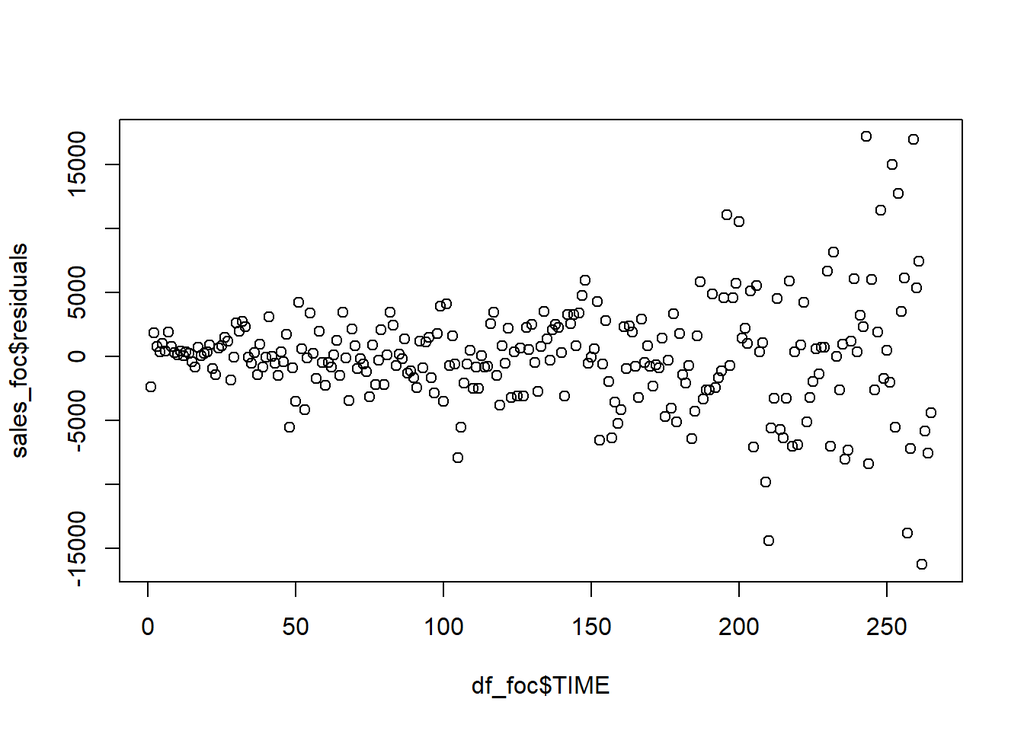

```
## The scatterplot between residuals and x-variable showcasing patterns suggesting there migh be heteroscadesticity
```

```r
plot(df_foc$TIME,sales_foc$residuals)
```

```r
resid_sq <- (sales_foc$residuals)^2

model_sum <- summary(lm(resid_sq~ df_foc$TIME +I(df_foc$TIME^2)))

chisq_val = model_sum$r.squared*nrow(df_foc)

pchisq(chisq_val,df = 2,lower.tail = FALSE)
```

```
## [1] 6.03505e-15
```

```
## As the p-value less than the 0.05 significance value, we can reject the null hypothesis and infer that there is high heteroscadesticity
```

```r
model_12_2 <- lm(log(SALES)~TIME,df_foc)
summary(model_12_2)
```

```
##
## Call:
## lm(formula = log(SALES) ~ TIME, data = df_foc)
##
## Residuals:
##      Min       1Q   Median       3Q      Max
## -1.24237 -0.13259  0.03325  0.19477  0.53935
##
## Coefficients:
##              Estimate Std. Error t value Pr(>|t|)
## (Intercept) 8.7390327  0.0342976  254.80   <2e-16 ***
## TIME        0.0053746  0.0002235   24.04   <2e-16 ***
## ---
## Signif. codes:  0 '***' 0.001 '**' 0.01 '*' 0.05 '.' 0.1 ' ' 1
##
## Residual standard error: 0.2784 on 263 degrees of freedom
## Multiple R-squared:  0.6873, Adjusted R-squared:  0.6861
## F-statistic: 578.1 on 1 and 263 DF,  p-value: < 2.2e-16
```

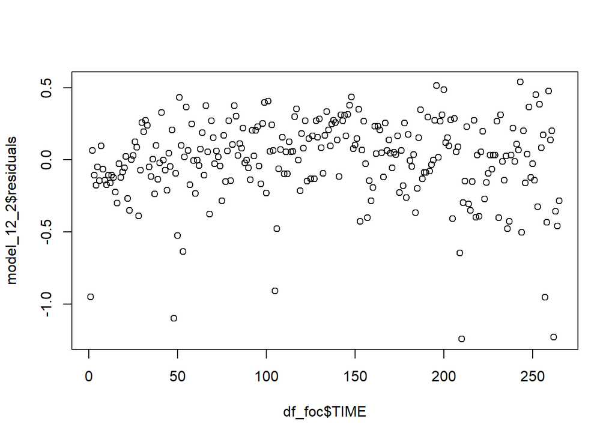

```
## In the scatterplot, there is no significant pattern, we can assume that the heteroscadesticity has been reduced
```

```r
plot(df_foc$TIME,model_12_2$residuals)
```

```r
resid_sq_2 <- (model_12_2$residuals)^2

model_sum_2 <- summary(lm(resid_sq_2~ df_foc$TIME +I(df_foc$TIME^2)))

chisq_val_2 = model_sum_2$r.squared*nrow(df_foc)

pchisq(chisq_val_2,df = 2,lower.tail = FALSE)
```

```
## [1] 0.006639661
```

```
## As the P-value suggests a statistically high signicant evidence for the presence of heteroscedasticity but it is less significant than earlier
```

```r
exp(predict(model_12_2,data.frame(TIME= 300)))
```

```
##       1
## 31301.4
```

```
## The prediction for 300th week is 31301.4
```

## Question-13

```r
df_woody <- read.csv("Woody.csv")
head(df_woody,2)
```

```
##   OBS      Y N      P     I
## 1   1 107919 3  65044 13240
## 2   2 118866 5 101376 22554
```

```r
woody <- lm(Y ~ N + P + I, data = df_woody)

summary(woody)
```

```
##
## Call:
## lm(formula = Y ~ N + P + I, data = df_woody)
##
## Residuals:
##    Min     1Q Median     3Q    Max
## -21923  -8627  -2956   5328  33887
##
## Coefficients:
##               Estimate Std. Error t value Pr(>|t|)
## (Intercept)  1.022e+05  1.280e+04   7.984 8.35e-09 ***
## N           -9.075e+03  2.053e+03  -4.421 0.000126 ***
## P            3.547e-01  7.268e-02   4.880 3.54e-05 ***
## I            1.288e+00  5.433e-01   2.371 0.024623 *
## ---
## Signif. codes:  0 '***' 0.001 '**' 0.01 '*' 0.05 '.' 0.1 ' ' 1
##
## Residual standard error: 14540 on 29 degrees of freedom
## Multiple R-squared:  0.6182, Adjusted R-squared:  0.5787
## F-statistic: 15.65 on 3 and 29 DF,  p-value: 3.058e-06
```

$H_{0} : \alpha_{1} = \alpha_{2} = 0$

$H_{1}$ : At least one alpha is not equal to zero

```r
resid_sq <- (woody$residuals)^2

aux_bre <- summary(lm(resid_sq ~ df_woody$N + df_woody$P + df_woody$I))

chisq_val = aux_bre$r.squared*nrow(df_woody)

pchisq(chisq_val,df = 3,lower.tail = FALSE)
```

```
## [1] 0.692793
```

```
## As the p-value greater than 0.05, we fail reject the null hypothesis, suggesting that there is no statistically significant evidence for signs of Heteroscedasticity
```

```r
lmtest::bptest(woody)
```

```
##
##  studentized Breusch-Pagan test
##
## data:  woody
## BP = 1.4546, df = 3, p-value = 0.6928
```

```
## The P-values from bptest is same as the calculations
```

```r
woody_white <- summary(lm(resid_sq ~ N + P + I + I(N^2) + I(P^2) + I(I^2) + N*P+ P*I + N*I + N*P*I,df_woody ))

chisq_val = woody_white$r.squared*nrow(df_woody)

pchisq(chisq_val,df = 10,lower.tail = FALSE)
```

```
## [1] 0.5355695
```

```
## The P-value suggests that there is no statistically signicant evidence for the presence of heteroscedasticity
```

```r
model_ko <- lm(resid_sq ~ I(woody$fitted.values^2))
summary(model_ko)
```

```
##
## Call:
## lm(formula = resid_sq ~ I(woody$fitted.values^2))
##
## Residuals:
##        Min         1Q     Median         3Q        Max
## -302859988 -151567444 -104857511   79314305  946118656
##
## Coefficients:
##                           Estimate Std. Error t value Pr(>|t|)
## (Intercept)              1.827e+07  1.815e+08   0.101    0.920
## I(woody$fitted.values^2) 1.042e-02  1.086e-02   0.959    0.345
##
## Residual standard error: 284100000 on 31 degrees of freedom
## Multiple R-squared:  0.02884,    Adjusted R-squared:  -0.002492
## F-statistic: 0.9205 on 1 and 31 DF,  p-value: 0.3448
```

```
## Koenker-Bassett test is inline with the other tests, since its p-value greater than the significance value suggesting that there is no heteroscadesiticity
```

# Question-14

```r
df_eco <- read.csv("EconomistSalary.csv")
```

```r
df_eco$Age <- c(22,27,32,37,42,47,52,57,62,67,70)
df_eco$Salary <- as.numeric(gsub(',',"",df_eco$Median.salary....))
```

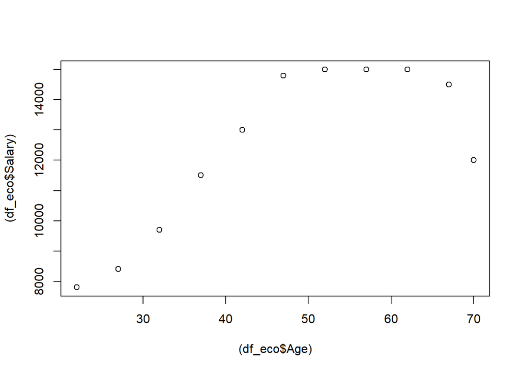

```r
plot((df_eco$Age),(df_eco$Salary))
```

```r
sal_age <- lm(Salary ~ Age, data = df_eco)

summary(sal_age)
```

```
##
## Call:
## lm(formula = Salary ~ Age, data = df_eco)
##
## Residuals:
##     Min      1Q  Median      3Q     Max
## -3505.4 -1045.8   376.4  1216.6  2348.6
##
## Coefficients:
##             Estimate Std. Error t value Pr(>|t|)
## (Intercept)  6210.67    1731.74   3.586  0.00587 **
## Age           132.78      35.11   3.782  0.00433 **
## ---
## Signif. codes:  0 '***' 0.001 '**' 0.01 '*' 0.05 '.' 0.1 ' ' 1
##
## Residual standard error: 1808 on 9 degrees of freedom
## Multiple R-squared:  0.6138, Adjusted R-squared:  0.5709
## F-statistic: 14.31 on 1 and 9 DF,  p-value: 0.004334
```

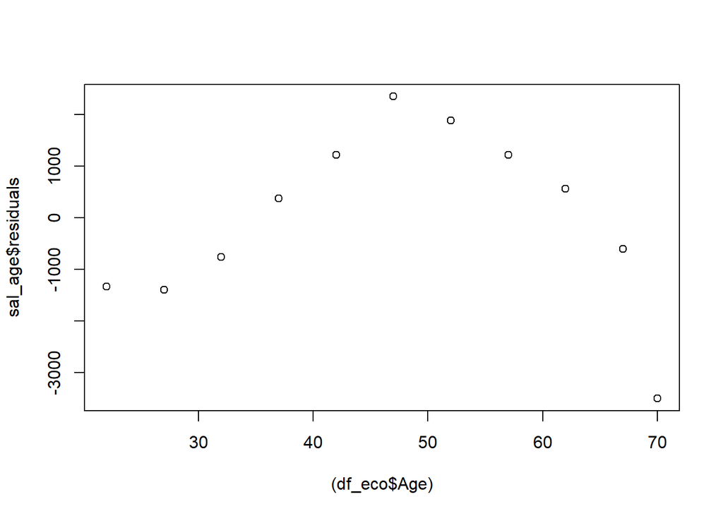

```r
plot((df_eco$Age),sal_age$residuals)
```

```r
cat("From both the residual plot and normal (y~x) plot we can see that the salary are trending with the age and decreasing after some point, there is a clear trend with respective to the age.")
```

```
## From both the residual plot and normal (y~x) plot we can see that the salary are trending with the age and decreasing after some point, there is a clear trend with respective to the age.
```

# Question 14.b

```r
y_14b <- (df_eco$Salary/sqrt(df_eco$Age))
x1 <- 1/sqrt(df_eco$Age)
x2 <- sqrt(df_eco$Age)
model_prop_x <- lm(y_14b ~ 0 + x1+ x2)
summary(model_prop_x)
```

```
##
## Call:
## lm(formula = y_14b ~ 0 + x1 + x2)
##
## Residuals:
##     Min      1Q  Median      3Q     Max
## -489.70 -143.00   21.51  166.67  341.90
##
## Coefficients:
##    Estimate Std. Error t value Pr(>|t|)
## x1  5015.61    1373.20   3.652 0.005297 **
## x2   158.31      31.32   5.054 0.000687 ***
## ---
## Signif. codes:  0 '***' 0.001 '**' 0.01 '*' 0.05 '.' 0.1 ' ' 1
##
## Residual standard error: 249.5 on 9 degrees of freedom
## Multiple R-squared:  0.9851, Adjusted R-squared:  0.9818
## F-statistic: 298.1 on 2 and 9 DF,  p-value: 5.967e-09
```

# Question 14.c

```r
y_14c <- (df_eco$Salary/(df_eco$Age))
x1_c <- 1/(df_eco$Age)
model_prop_x_sq <- lm(y_14c ~ x1_c)
summary(model_prop_x_sq)
```

```
##
## Call:
## lm(formula = y_14c ~ x1_c)
##
## Residuals:
##     Min      1Q  Median      3Q     Max
## -67.168 -17.877  -4.326  24.267  47.227
##
## Coefficients:
##             Estimate Std. Error t value Pr(>|t|)
## (Intercept)   179.19      28.13   6.369  0.00013 ***
## x1_c         4158.32    1075.38   3.867  0.00381 **
## ---
## Signif. codes:  0 '***' 0.001 '**' 0.01 '*' 0.05 '.' 0.1 ' ' 1
##
## Residual standard error: 34.03 on 9 degrees of freedom
## Multiple R-squared:  0.6243, Adjusted R-squared:  0.5825
## F-statistic: 14.95 on 1 and 9 DF,  p-value: 0.003807
```

## Question- 14.D

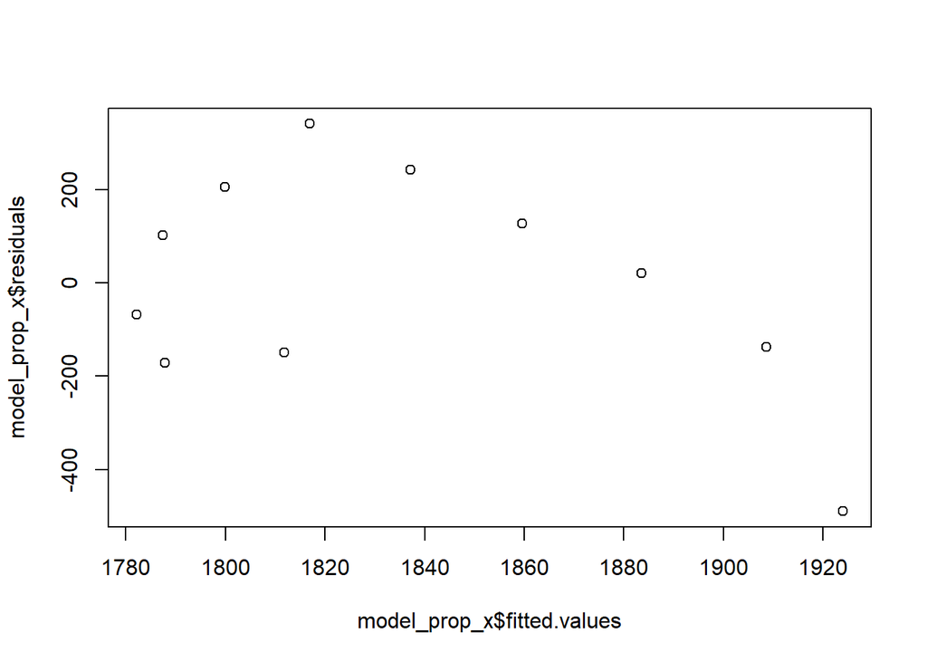

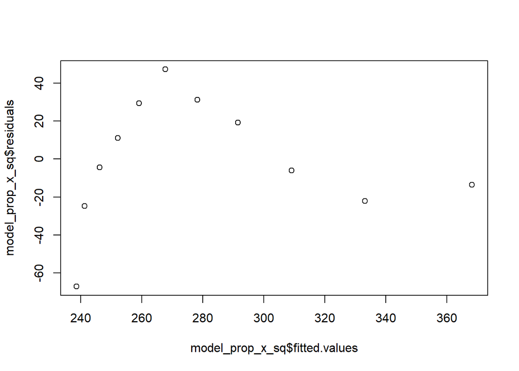

```
## From the scatter plots between the residuals and respective Y's we can clearly there is a pattern between the Residuals and Ys. We need to conduct formal tests to confirm the same
```

```r
plot(model_prop_x$residuals~model_prop_x$fitted.values)
plot(model_prop_x_sq$residuals~model_prop_x_sq$fitted.values)
```

```r
summary(lm(log(sal_age$residuals^2)~log(df_eco$Age)))
```

```
##
## Call:
## lm(formula = log(sal_age$residuals^2) ~ log(df_eco$Age))
##
## Residuals:
##     Min      1Q  Median      3Q     Max
## -2.1475 -1.0507  0.1449  0.7692  2.0781
##
## Coefficients:
##                 Estimate Std. Error t value Pr(>|t|)
## (Intercept)       12.665      4.379   2.893   0.0178 *
## log(df_eco$Age)    0.372      1.152   0.323   0.7541
## ---
## Signif. codes:  0 '***' 0.001 '**' 0.01 '*' 0.05 '.' 0.1 ' ' 1
##
## Residual standard error: 1.393 on 9 degrees of freedom
## Multiple R-squared:  0.01146,    Adjusted R-squared:  -0.09838
## F-statistic: 0.1043 on 1 and 9 DF,  p-value: 0.7541
```

```r
summary(lm(log(model_prop_x$residuals^2) ~ log(x1)))
```

```
##
## Call:
## lm(formula = log(model_prop_x$residuals^2) ~ log(x1))
##
## Residuals:
##     Min      1Q  Median      3Q     Max
## -3.8908 -0.4703  0.2386  0.8648  2.3298
##
## Coefficients:
##             Estimate Std. Error t value Pr(>|t|)
## (Intercept)   8.9937     5.5371   1.624    0.139
## log(x1)      -0.5009     2.9129  -0.172    0.867
##
## Residual standard error: 1.761 on 9 degrees of freedom
## Multiple R-squared:  0.003275,   Adjusted R-squared:  -0.1075
## F-statistic: 0.02957 on 1 and 9 DF,  p-value: 0.8673
```

```r
summary(lm(log(model_prop_x$residuals^2) ~ log(x2)))
```

```
##
## Call:
## lm(formula = log(model_prop_x$residuals^2) ~ log(x2))
##
## Residuals:
##     Min      1Q  Median      3Q     Max
## -3.8908 -0.4703  0.2386  0.8648  2.3298
##
## Coefficients:
##             Estimate Std. Error t value Pr(>|t|)
## (Intercept)   8.9937     5.5371   1.624    0.139
## log(x2)       0.5009     2.9129   0.172    0.867
##
## Residual standard error: 1.761 on 9 degrees of freedom
## Multiple R-squared:  0.003275,   Adjusted R-squared:  -0.1075
## F-statistic: 0.02957 on 1 and 9 DF,  p-value: 0.8673
```

```r
summary(lm(log(model_prop_x_sq$residuals^2) ~ log(x1_c)))
```

```
##
## Call:
## lm(formula = log(model_prop_x_sq$residuals^2) ~ log(x1_c))
##
## Residuals:
##     Min      1Q  Median      3Q     Max
## -3.2839 -0.6794  0.1794  0.8933  2.0885
##
## Coefficients:
##             Estimate Std. Error t value Pr(>|t|)
## (Intercept)   2.3807     5.3690   0.443    0.668
## log(x1_c)    -0.9286     1.4123  -0.658    0.527
##
## Residual standard error: 1.708 on 9 degrees of freedom
## Multiple R-squared:  0.04584,    Adjusted R-squared:  -0.06018
## F-statistic: 0.4323 on 1 and 9 DF,  p-value: 0.5273
```

[output not shown]

## Question-15

```r
df_ski <- read.csv("SkiSales.csv")
head(df_ski,2)
```

```
##   Tickets Snowfall Temperature
## 1    6835       19          11
## 2    7870       15         -19
```

```r
model_tick <- lm(Tickets~Snowfall + Temperature, df_ski)
summary(model_tick)
```

```
##
## Call:
## lm(formula = Tickets ~ Snowfall + Temperature, data = df_ski)
##
## Residuals:
##     Min      1Q  Median      3Q     Max
## -2794.0 -1445.6   192.3  1349.4  2515.6
##
## Coefficients:
##             Estimate Std. Error t value Pr(>|t|)
## (Intercept) 8308.011    903.728   9.193 5.24e-08 ***
## Snowfall      74.593     51.575   1.446    0.166
## Temperature   -8.754     19.704  -0.444    0.662
## ---
## Signif. codes:  0 '***' 0.001 '**' 0.01 '*' 0.05 '.' 0.1 ' ' 1
##
## Residual standard error: 1712 on 17 degrees of freedom
## Multiple R-squared:   0.12,  Adjusted R-squared:  0.0165
## F-statistic: 1.159 on 2 and 17 DF,  p-value: 0.3373
```

# Normality test

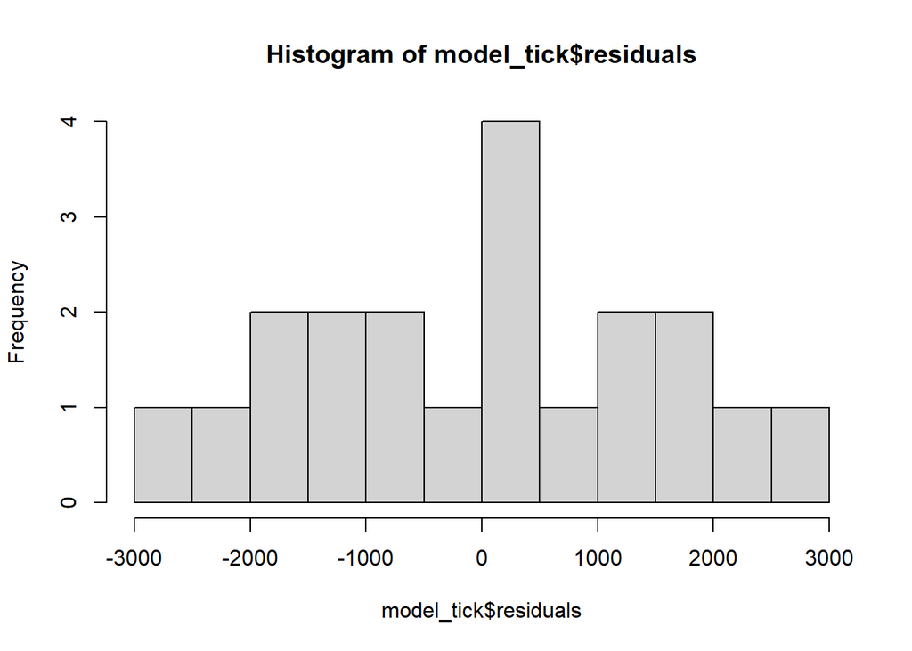

```r
hist(model_tick$residuals,breaks=8)
```

```r
shapiro.test(model_tick$residuals)
```

```
##
##  Shapiro-Wilk normality test
##
## data:  model_tick$residuals
## W = 0.96002, p-value = 0.5442
```

```r
cat("As the p-value greater than the significance value, we can suggest that the residuals are normal in distribution")
```

```
## As the p-value greater than the significance value, we can suggest that the residuals are normal in distribution
```

# Independence test - Autocorrelation

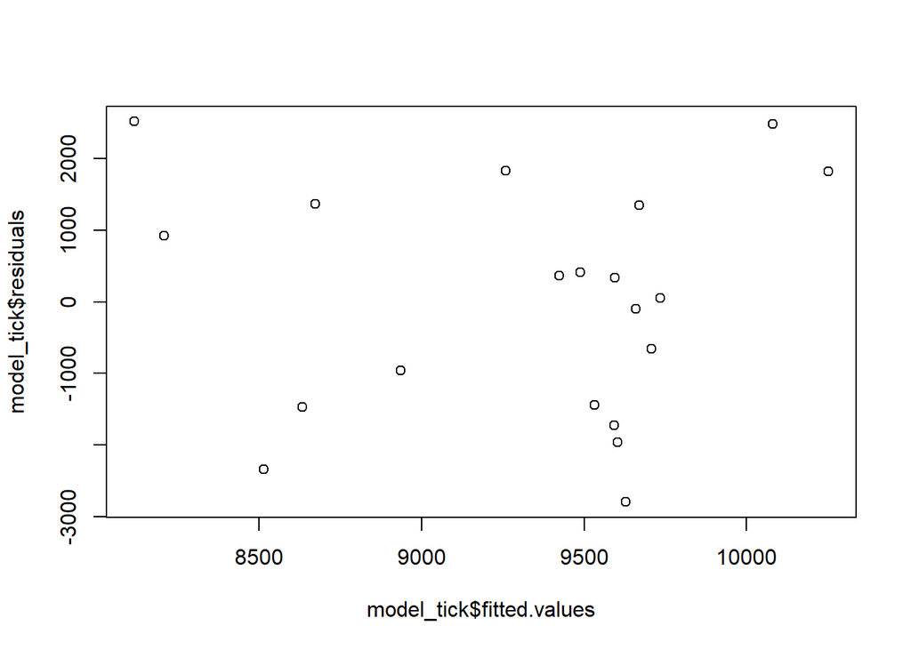

```r
plot(model_tick$fitted.values , model_tick$residuals)
```

```r
lmtest::dwtest(model_tick)
```

```
##
##  Durbin-Watson test
##
## data:  model_tick
## DW = 0.59314, p-value = 0.0001906
## alternative hypothesis: true autocorrelation is greater than 0
```

```
## As p-value less than the significant value, we can state that there is autocorrelation
```

# Constant Variance Test - Heteroscadesticity

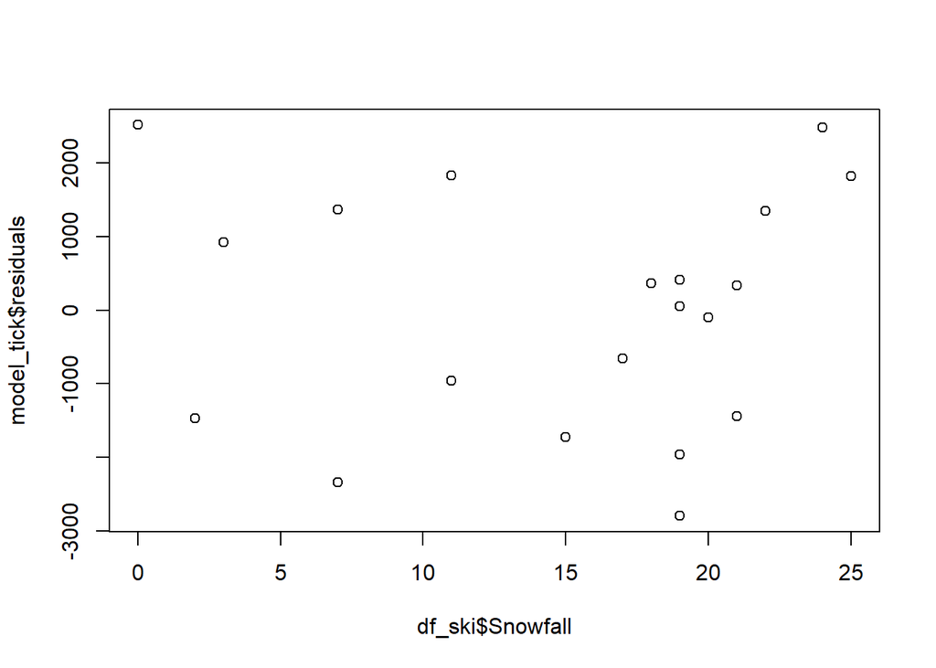

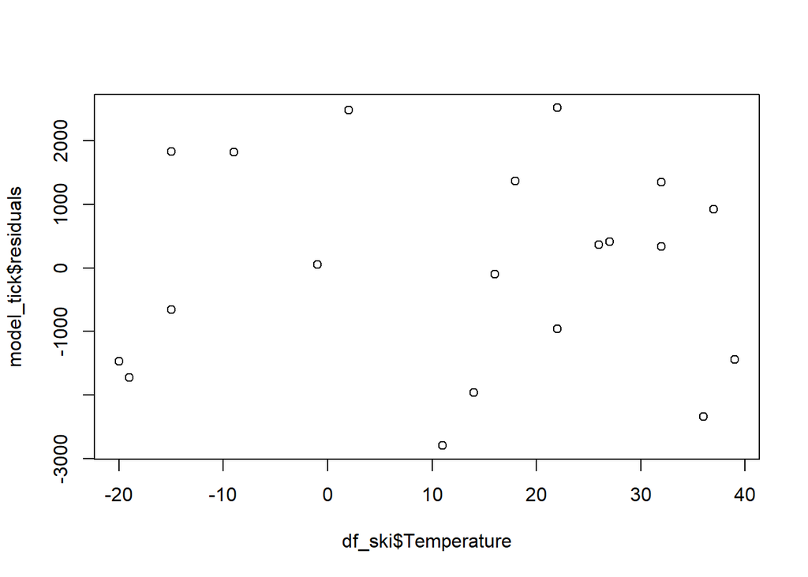

```
## Due to small number of data points and not to lose any more df, conducting the Modified White's  test
```

```r
plot(model_tick$residuals~df_ski$Snowfall)
plot(model_tick$residuals~df_ski$Temperature)
```

```r
model_tick_resid <- model_tick$residuals^2
model_tick_fitted_val_sq <- model_tick$fitted.values^2
summary(lm(model_tick_resid ~ model_tick$fitted.values + model_tick_fitted_val_sq))
```

```
##
## Call:
## lm(formula = model_tick_resid ~ model_tick$fitted.values + model_tick_fitted_val_sq)
##
## Residuals:
##      Min       1Q   Median       3Q      Max
## -3241101 -1676440  -380561  1752169  5743071
##
## Coefficients:
##                            Estimate Std. Error t value Pr(>|t|)
## (Intercept)               2.194e+08  1.276e+08   1.719    0.104
## model_tick$fitted.values -4.738e+04  2.807e+04  -1.688    0.110
## model_tick_fitted_val_sq  2.576e+00  1.538e+00   1.675    0.112
##
## Residual standard error: 2329000 on 17 degrees of freedom
## Multiple R-squared:  0.1494, Adjusted R-squared:  0.04936
## F-statistic: 1.493 on 2 and 17 DF,  p-value: 0.2527
```

```
## As p-value greater than the significance value, we can suggest there is no heteroscadesticity
```

```r
df_ski$trend <- 1:nrow(df_ski)
```

```r
model_tick_trend <- lm(Tickets~Snowfall + Temperature + trend, df_ski)
summary(model_tick_trend)
```

```
##
## Call:
## lm(formula = Tickets ~ Snowfall + Temperature + trend, data = df_ski)
##
## Residuals:
##      Min       1Q   Median       3Q      Max
## -1584.41  -593.14   -82.81   575.84  1512.10
##
## Coefficients:
##             Estimate Std. Error t value Pr(>|t|)
## (Intercept) 5965.588    631.252   9.450 6.00e-08 ***
## Snowfall      70.183     28.851   2.433   0.0271 *
## Temperature   -9.233     11.020  -0.838   0.4145
## trend        229.970     37.132   6.193 1.29e-05 ***
## ---
## Signif. codes:  0 '***' 0.001 '**' 0.01 '*' 0.05 '.' 0.1 ' ' 1
##
## Residual standard error: 957.2 on 16 degrees of freedom
## Multiple R-squared:  0.741,  Adjusted R-squared:  0.6924
## F-statistic: 15.26 on 3 and 16 DF,  p-value: 5.934e-05
```

# Test for autocorrelation

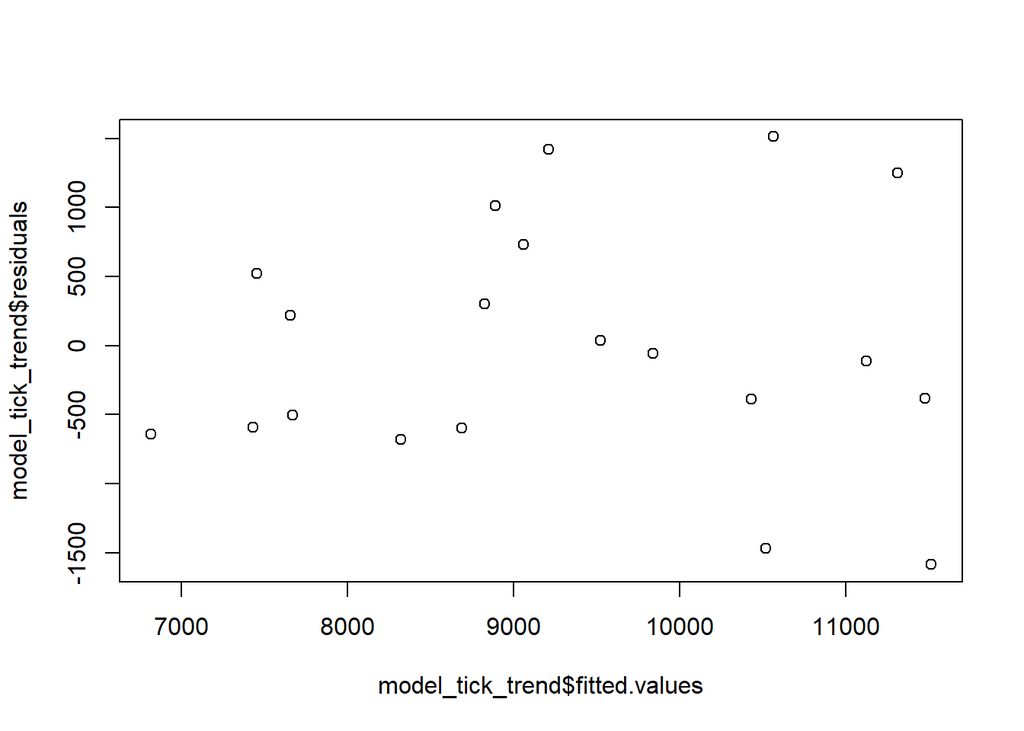

[output not shown]

```
## After introducing the trend variable, we can clearly see that there is no autocorrelation
```

```r
plot(model_tick_trend$fitted.values , model_tick_trend$residuals)
```

## Question-16

```r
df_cp <- read.csv("CompensationAndProductivity.csv")
head(df_cp,2)
```

```
##   Year    Y    X
## 1 1960 60.8 48.9
## 2 1961 62.5 50.6
```

```r
model16_1 <- lm(Y~X,df_cp)
summary(model16_1)
```

```
##
## Call:
## lm(formula = Y ~ X, data = df_cp)
##
## Residuals:
##     Min      1Q  Median      3Q     Max
## -4.7247 -1.9665  0.3394  2.0095  3.9586
##
## Coefficients:
##             Estimate Std. Error t value Pr(>|t|)
## (Intercept) 32.74190    1.39402   23.49   <2e-16 ***
## X            0.67041    0.01567   42.78   <2e-16 ***
## ---
## Signif. codes:  0 '***' 0.001 '**' 0.01 '*' 0.05 '.' 0.1 ' ' 1
##
## Residual standard error: 2.384 on 44 degrees of freedom
## Multiple R-squared:  0.9765, Adjusted R-squared:  0.976
## F-statistic:  1830 on 1 and 44 DF,  p-value: < 2.2e-16
```

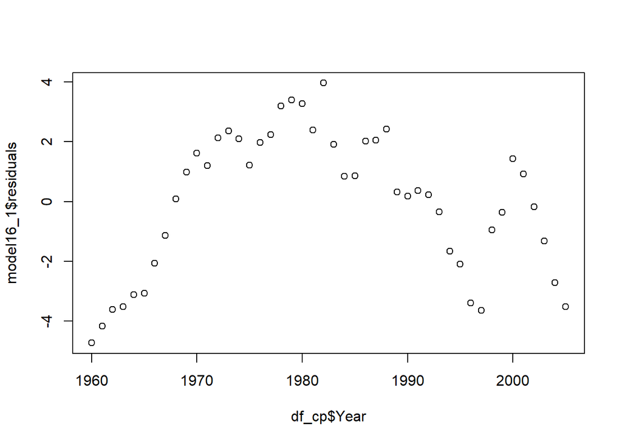

```r
plot(df_cp$Year,model16_1$residuals)
```

```r
lmtest::dwtest(model16_1)
```

```
##
##  Durbin-Watson test
##
## data:  model16_1
## DW = 0.17389, p-value < 2.2e-16
## alternative hypothesis: true autocorrelation is greater than 0
```

```
## From the scatter plot and durbin watson test, we can conclude that there is evidence of Positive Autocorrelation
```

```r
df_cp$trend <- 1:nrow(df_cp)
model16_2 <- lm(Y ~ X + trend,df_cp)
summary(model16_2)
```

```
##
## Call:
## lm(formula = Y ~ X + trend, data = df_cp)
##
## Residuals:
##     Min      1Q  Median      3Q     Max
## -4.5031 -1.5141  0.3285  1.7550  3.3411
##
## Coefficients:
##             Estimate Std. Error t value Pr(>|t|)
## (Intercept) 39.87087    4.20831   9.474 4.33e-12 ***
## X            0.51462    0.08836   5.824 6.58e-07 ***
## trend        0.26730    0.14932   1.790   0.0805 .
## ---
## Signif. codes:  0 '***' 0.001 '**' 0.01 '*' 0.05 '.' 0.1 ' ' 1
##
## Residual standard error: 2.327 on 43 degrees of freedom
## Multiple R-squared:  0.9782, Adjusted R-squared:  0.9771
## F-statistic: 962.6 on 2 and 43 DF,  p-value: < 2.2e-16
```

```r
lmtest::dwtest(model16_2)
```

```
##
##  Durbin-Watson test
##
## data:  model16_2
## DW = 0.18303, p-value < 2.2e-16
## alternative hypothesis: true autocorrelation is greater than 0
```

```
## No change in autocorrelation by including the trend variable in the model
```

```r
df_cp$lagy <- lag(df_cp$Y,1)
```

```r
model16_3 <- lm(Y ~ X + lagy, df_cp)

summary(model16_3)
```

```
##
## Call:
## lm(formula = Y ~ X + lagy, data = df_cp)
##
## Residuals:
##      Min       1Q   Median       3Q      Max
## -2.07132 -0.71078 -0.02101  0.57252  2.32623
##
## Coefficients:
##             Estimate Std. Error t value Pr(>|t|)
## (Intercept)  9.09987    1.99885   4.553 4.49e-05 ***
## X            0.16698    0.03902   4.280 0.000106 ***
## lagy         0.75173    0.05826  12.903 3.32e-16 ***
## ---
## Signif. codes:  0 '***' 0.001 '**' 0.01 '*' 0.05 '.' 0.1 ' ' 1
##
## Residual standard error: 1.041 on 42 degrees of freedom
##   (1 observation deleted due to missingness)
## Multiple R-squared:  0.9953, Adjusted R-squared:  0.9951
## F-statistic:  4482 on 2 and 42 DF,  p-value: < 2.2e-16
```

```
## The overmodel is significantly valid and even the lag term of Y is significant in explaining the variance of the Y. So, we can state the lag term is a missing varible as the Adj-R2 increasing as well.
```

```r
d = lmtest::dwtest(model16_3)
rho = 1-(d$statistic/2)
var_lag <- 0.05826^2

h_stat <- (rho*sqrt(nrow(df_cp)/(1-nrow(df_cp)*var_lag)))
h_stat
```

```
##       DW
## 2.301844
```

```
## Since the h_stat is greater than the 1.96, we can reject the null hypothesis and state that there is first-order autocorrelation.
##  Due to the presence of the first order autocorrelation including a trend variable didn't help to solve the issue.
```

## Question-17

```r
df_diet <- read.csv("DietEffect.csv")
head(df_diet,2)
```

```
##   ID.number Diet. Time Letters Words  X
## 1         1     2  584       2     2 NA
## 2         2     1  639       2     2 NA
```

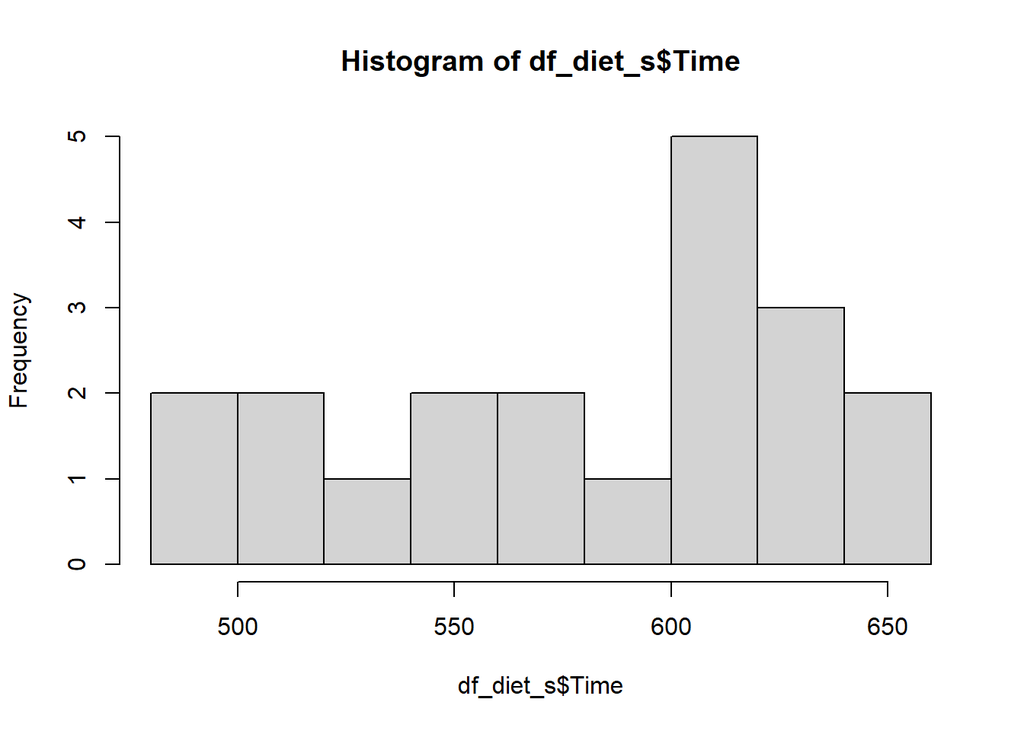

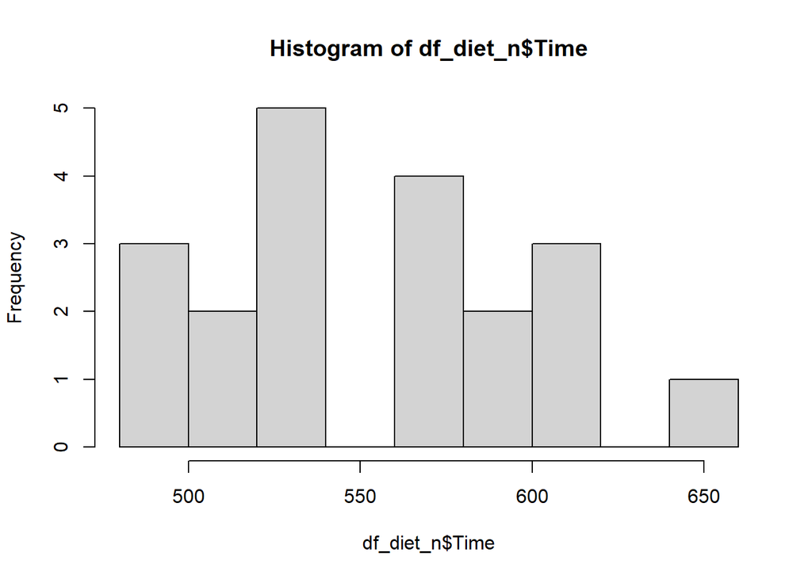

```r
df_diet_s <- subset(df_diet, Diet. ==1)
df_diet_n <- subset(df_diet, Diet. ==2)
hist(df_diet_s$Time)
hist(df_diet_n$Time)
```

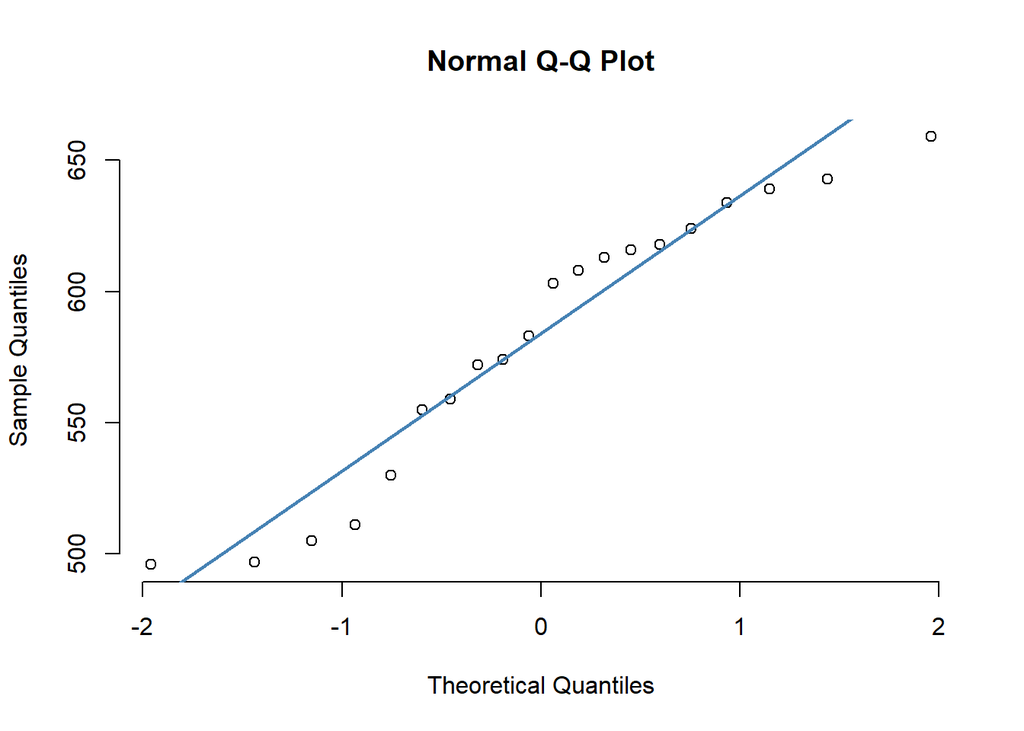

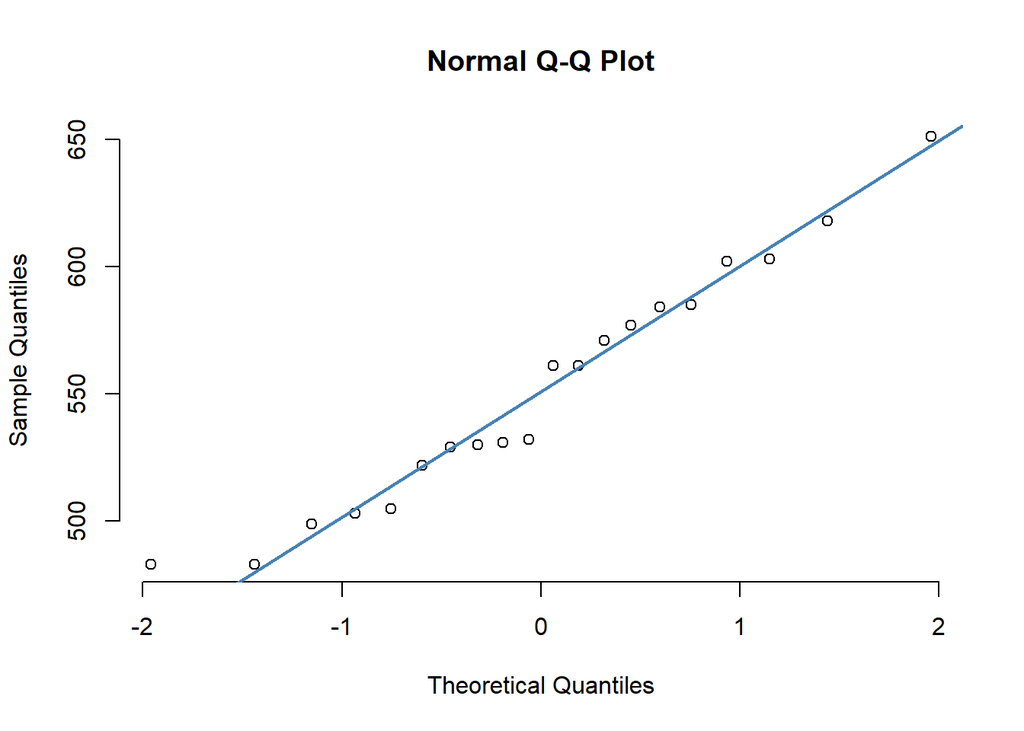

```r
qqnorm(df_diet_s$Time, pch = 1, frame = FALSE)
qqline(df_diet_s$Time, col = "steelblue", lwd = 2)

qqnorm(df_diet_n$Time, pch = 1, frame = FALSE)
qqline(df_diet_n$Time, col = "steelblue", lwd = 2)
```

```r
shapiro.test(df_diet_s$Time)
```

```
##
##  Shapiro-Wilk normality test
##
## data:  df_diet_s$Time
## W = 0.92673, p-value = 0.1336
```

```r
shapiro.test(df_diet_n$Time)
```

```
##
##  Shapiro-Wilk normality test
##
## data:  df_diet_n$Time
## W = 0.96113, p-value = 0.5666
```

```
## From the above normality test we can infer that the times are normal.
```

```r
var.test(df_diet_s$Time,df_diet_n$Time)
```

```
##
##  F test to compare two variances
##
## data:  df_diet_s$Time and df_diet_n$Time
## F = 1.2228, num df = 19, denom df = 19, p-value = 0.6655
## alternative hypothesis: true ratio of variances is not equal to 1
## 95 percent confidence interval:
##  0.4840158 3.0894510
## sample estimates:
## ratio of variances
##           1.222842
```

```
## Two variances are equal
```

**Hypothesis:**  
$H_{o}$ : $\mu_{1}$ - $\mu_{2}$ = 0  
$H_{1}$ : $\mu_{1}$ - $\mu_{2}$ < 0

```r
t.test(df_diet_s$Time,df_diet_n$Time,
       var.equal = T,
       mu = 0,
       alternative = 'l')
```

```
##
##  Two Sample t-test
##
## data:  df_diet_s$Time and df_diet_n$Time
## t = 1.9379, df = 38, p-value = 0.97
## alternative hypothesis: true difference in means is less than 0
## 95 percent confidence interval:
##      -Inf 56.94177
## sample estimates:
## mean of x mean of y
##    581.95    551.50
```

```
## As the p-value is greater than the significance value, we failed to reject the null hypothesis and suggest that the dieting has no adverse impact on the time to solve problems
```

**Hypothesis:**  
$H_{o}$ : Dieting and answering the questions are independent  
$H_{1}$ : Dieting and answering the questions are dependent

```r
chisq.test(df_diet$Diet.,df_diet$Letters)
```

```
##
##  Pearson's Chi-squared test with Yates' continuity correction
##
## data:  df_diet$Diet. and df_diet$Letters
## X-squared = 2.7473, df = 1, p-value = 0.09742
```

```r
chisq.test(df_diet$Diet.,df_diet$Letters, correct=FALSE)
```

```
##
##  Pearson's Chi-squared test
##
## data:  df_diet$Diet. and df_diet$Letters
## X-squared = 3.956, df = 1, p-value = 0.0467
```

[output not shown]

```r
chisq.test(df_diet$Diet.,df_diet$Words)
```

```
##
##  Pearson's Chi-squared test with Yates' continuity correction
##
## data:  df_diet$Diet. and df_diet$Words
## X-squared = 1.604, df = 1, p-value = 0.2053
```

```r
chisq.test(df_diet$Diet.,df_diet$Words, correct=FALSE)
```

```
##
##  Pearson's Chi-squared test
##
## data:  df_diet$Diet. and df_diet$Words
## X-squared = 2.5063, df = 1, p-value = 0.1134
```

```r
cat("Note: Chi-square has been done with and without Yates continuinty based on the discussion with Professor")
```

```
## Note: Chi-square has been done with and without Yates continuinty based on the discussion with Professor
```

[output not shown]

```
## So, finally we can conclude there is no statistical evidence that the dieting has affect on brain
```

## Question-18

```r
df_cons <- read.csv("Consumption.csv")
head(df_cons,2)
```

```
##      con    dpi        aaa year
## 1 1061.5 1383.1  0.3199999 1945
## 2 1193.6 1368.6 -5.9700000 1946
```

#18.a

```r
model18_1 <- lm(con ~ dpi + aaa, df_cons)
summary(model18_1)
```

```
##
## Call:
## lm(formula = con ~ dpi + aaa, data = df_cons)
##
## Residuals:
##      Min       1Q   Median       3Q      Max
## -193.670  -66.484    6.578   60.291  223.573
##
## Coefficients:
##               Estimate Std. Error t value Pr(>|t|)
## (Intercept) -1.654e+02  2.309e+01  -7.165 1.42e-09 ***
## dpi          9.320e-01  4.861e-03 191.726  < 2e-16 ***
## aaa         -1.254e+01  3.804e+00  -3.297  0.00166 **
## ---
## Signif. codes:  0 '***' 0.001 '**' 0.01 '*' 0.05 '.' 0.1 ' ' 1
##
## Residual standard error: 91.18 on 59 degrees of freedom
## Multiple R-squared:  0.9987, Adjusted R-squared:  0.9987
## F-statistic: 2.28e+04 on 2 and 59 DF,  p-value: < 2.2e-16
```

# 18.b

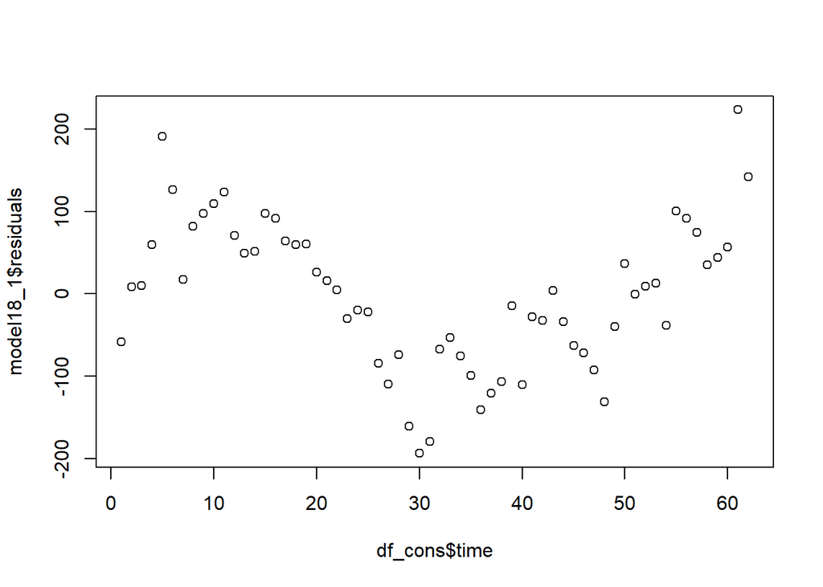

```
## The scatterplot doesn't seem to be entirely a random. It contains some systematic pattern maybe caused by the lag factors or external factors
```

```r
df_cons$time <- 1:nrow(df_cons)
plot(df_cons$time,model18_1$residuals)
```

#18.c

**Hypothesis:**  
$H_{o}$ : No evidence of positive autocorrelation  
$H_{1}$ : Evidence of positive autocorrelation

```r
lmtest::dwtest(model18_1)
```

```
##
##  Durbin-Watson test
##
## data:  model18_1
## DW = 0.38577, p-value < 2.2e-16
## alternative hypothesis: true autocorrelation is greater than 0
```

```
## As p-vlaue is less than the 0.05 significance, we can reject the null hypothesis and infer that there is positive autocorrelation
```

# 18.d

```r
resid_lag <- lag(model18_1$residuals,1)
summary(lm(model18_1$residuals ~ df_cons$dpi + df_cons$aaa + resid_lag))
```

```
##
## Call:
## lm(formula = model18_1$residuals ~ df_cons$dpi + df_cons$aaa +
##     resid_lag)
##
## Residuals:
##      Min       1Q   Median       3Q      Max
## -108.899  -34.550   -6.952   23.906  173.294
##
## Coefficients:
##               Estimate Std. Error t value Pr(>|t|)
## (Intercept) -1.8269396 14.1783324  -0.129    0.898
## df_cons$dpi  0.0002998  0.0029512   0.102    0.919
## df_cons$aaa  1.2519719  2.2930075   0.546    0.587
## resid_lag    0.8216334  0.0802650  10.237 1.59e-14 ***
## ---
## Signif. codes:  0 '***' 0.001 '**' 0.01 '*' 0.05 '.' 0.1 ' ' 1
##
## Residual standard error: 54.86 on 57 degrees of freedom
##   (1 observation deleted due to missingness)
## Multiple R-squared:  0.6477, Adjusted R-squared:  0.6292
## F-statistic: 34.94 on 3 and 57 DF,  p-value: 6.034e-13
```

```r
chisq <- (nrow(df_cons) - 3)*(0.6477)
pchisq(chisq,df =3,lower.tail = FALSE)
```

```
## [1] 2.54608e-08
```

```
## The lagrange-multipier test also suggesting the same thing as Durbin-Watson that the autocorrelation exists
```

# 18.e

```r
n <- nrow(df_cons)
d <- 0.38577
k <- 3
rho_hat <- (n^2*(1-d/2)+k^2)/(n^2 - k^2)
```

```r
y_lag <-  lag(df_cons$con, 1)
aaa_lag <-  lag(df_cons$aaa, 1)
dpi_lag <-  lag(df_cons$dpi,1)

y_final <- df_cons$con - rho_hat*y_lag
aaa_final <- df_cons$aaa - rho_hat*aaa_lag
dpi_final <- df_cons$dpi - rho_hat*dpi_lag

y_final[1] <- df_cons$con[1]*sqrt(1-rho_hat^2)
aaa_final[1] <- df_cons$aaa[1]*sqrt(1-rho_hat^2)
dpi_final[1] <- df_cons$dpi[1]*sqrt(1-rho_hat^2)
```

```r
model_gls <- lm(y_final ~ aaa_final + dpi_final)
summary(model_gls)
```

```
##
## Call:
## lm(formula = y_final ~ aaa_final + dpi_final)
##
## Residuals:
##     Min      1Q  Median      3Q     Max
## -105.23  -33.95   -3.09   23.02  184.57
##
## Coefficients:
##              Estimate Std. Error t value Pr(>|t|)
## (Intercept) -33.51324   13.56095  -2.471   0.0164 *
## aaa_final    -5.02743    2.85140  -1.763   0.0831 .
## dpi_final     0.93162    0.01185  78.621   <2e-16 ***
## ---
## Signif. codes:  0 '***' 0.001 '**' 0.01 '*' 0.05 '.' 0.1 ' ' 1
##
## Residual standard error: 52.69 on 59 degrees of freedom
## Multiple R-squared:  0.9906, Adjusted R-squared:  0.9903
## F-statistic:  3107 on 2 and 59 DF,  p-value: < 2.2e-16
```

```
## For both the models, the coefficients are different except for slope coefficent for dpi. However, aaa has a different coefficient. The process of removing the autocorrelation is making the coefficients different. And intercept follows the beta_0 *(1-rho) property.
```

```r
lmtest::dwtest(model_gls)
```

```
##
##  Durbin-Watson test
##
## data:  model_gls
## DW = 2.0997, p-value = 0.5935
## alternative hypothesis: true autocorrelation is greater than 0
```

```
## The GLS model doesn't have the autocorrelation from the durbin-watson test
```

# 18.G

```r
sandwich::NeweyWest(model18_1)
```

```
##             (Intercept)         dpi         aaa
## (Intercept) 6541.487646 -1.40402111 311.6556448
## dpi           -1.404021  0.00041794  -0.1350706
## aaa          311.655645 -0.13507056  63.4827010
```

```r
summary(model18_1)
```

```
##
## Call:
## lm(formula = con ~ dpi + aaa, data = df_cons)
##
## Residuals:
##      Min       1Q   Median       3Q      Max
## -193.670  -66.484    6.578   60.291  223.573
##
## Coefficients:
##               Estimate Std. Error t value Pr(>|t|)
## (Intercept) -1.654e+02  2.309e+01  -7.165 1.42e-09 ***
## dpi          9.320e-01  4.861e-03 191.726  < 2e-16 ***
## aaa         -1.254e+01  3.804e+00  -3.297  0.00166 **
## ---
## Signif. codes:  0 '***' 0.001 '**' 0.01 '*' 0.05 '.' 0.1 ' ' 1
##
## Residual standard error: 91.18 on 59 degrees of freedom
## Multiple R-squared:  0.9987, Adjusted R-squared:  0.9987
## F-statistic: 2.28e+04 on 2 and 59 DF,  p-value: < 2.2e-16
```

```r
lmtest::coeftest(model18_1,vcov = sandwich::NeweyWest(model18_1))
```

```
##
## t test of coefficients:
##
##                Estimate  Std. Error t value Pr(>|t|)
## (Intercept) -165.444188   80.879464 -2.0456  0.04527 *
## dpi            0.932022    0.020444 45.5900  < 2e-16 ***
## aaa          -12.541959    7.967603 -1.5741  0.12081
## ---
## Signif. codes:  0 '***' 0.001 '**' 0.01 '*' 0.05 '.' 0.1 ' ' 1
```

# 18.H

```
## After applying NeweyWest method, the coefficients are same as the OLS output. The standard errors are adjusted for  Auto-correlation
```